# ANCOVA in flow (prob. matemática) (flow (prob. matemática))

Geiser C. Challco geiser@alumni.usp.br

- Descriptive Statistics of Initial Data
- ANCOVA and Pairwise for one factor: **grupo**
  - Without remove non-normal data
  - Computing ANCOVA and PairWise After removing non-normal data (OK)
    - Plots for ancova
    - Checking linearity assumption
    - Checking normality and homogeneity
- ANCOVA and Pairwise for two factors **grupo:Sexo**
  - Without remove non-normal data
  - Computing ANCOVA and PairWise After removing non-normal data (OK)
    - Plots for ancova
    - Checking linearity assumption
    - Checking normality and homogeneity
- ANCOVA and Pairwise for two factors **grupo:Zona**
  - Without remove non-normal data
  - Computing ANCOVA and PairWise After removing non-normal data (OK)
    - Plots for ancova
    - Checking linearity assumption
    - Checking normality and homogeneity
- ANCOVA and Pairwise for two factors **grupo:Cor.Raca**
  - Without remove non-normal data
  - Computing ANCOVA and PairWise After removing non-normal data (OK)
    - Plots for ancova
    - Checking linearity assumption
    - Checking normality and homogeneity
- Summary of Results
  - Descriptive Statistics
  - ANCOVA Table Comparison
  - PairWise Table Comparison
  - EMMS Table Comparison

**NOTE**:

- Teste ANCOVA para determinar se houve diferenças significativas no flow (prob. matemática) (medido usando pre- e pos-testes).
- ANCOVA test to determine whether there were significant differences in flow (prob. matemática) (measured using pre- and post-tests).

# Descriptive Statistics of Initial Data

```r
df <- get.descriptives(dat, c(dv.pre, dv.pos), c("grupo"),
                       include.global = T, symmetry.test = T, normality.test = F)
df <- plyr::rbind.fill(
  df, do.call(plyr::rbind.fill, lapply(lfatores2, FUN = function(f) {
    if (nrow(dat) > 0 && sum(!is.na(unique(dat[[f]]))) > 1)
      get.descriptives(dat, c(dv.pre,dv.pos), c("grupo", f),
                       symmetry.test = T, normality.test = F)
    }))
)
(df <- df[,c(fatores1[fatores1 %in% colnames(df)],"variable",
             colnames(df)[!colnames(df) %in% c(fatores1,"variable")])])
```

```
##           grupo Sexo   Zona Cor.Raca       variable   n  mean median   min   max    sd    se    ci   iqr
## 1      Controle <NA>   <NA>     <NA> dfs.media.math 136 3.280  3.292 1.333 4.667 0.619 0.053 0.105 0.889
## 2  Experimental <NA>   <NA>     <NA> dfs.media.math 198 3.468  3.444 2.111 5.000 0.557 0.040 0.078 0.667
## 3          <NA> <NA>   <NA>     <NA> dfs.media.math 334 3.392  3.333 1.333 5.000 0.589 0.032 0.063 0.778
## 4      Controle <NA>   <NA>     <NA> fss.media.math 136 3.155  3.111 1.778 4.625 0.537 0.046 0.091 0.778
## 5  Experimental <NA>   <NA>     <NA> fss.media.math 198 3.417  3.444 1.000 5.000 0.625 0.044 0.088 0.667
## 6          <NA> <NA>   <NA>     <NA> fss.media.math 334 3.311  3.333 1.000 5.000 0.604 0.033 0.065 0.778
## 7      Controle    F   <NA>     <NA> dfs.media.math  74 3.360  3.333 1.889 4.444 0.545 0.063 0.126 0.667
## 8      Controle    M   <NA>     <NA> dfs.media.math  62 3.185  3.111 1.333 4.667 0.688 0.087 0.175 0.889
## 9  Experimental    F   <NA>     <NA> dfs.media.math  95 3.360  3.333 2.222 5.000 0.529 0.054 0.108 0.778
## 10 Experimental    M   <NA>     <NA> dfs.media.math 103 3.568  3.556 2.111 4.667 0.565 0.056 0.110 0.667
## 11     Controle    F   <NA>     <NA> fss.media.math  74 3.144  3.111 1.778 4.125 0.478 0.056 0.111 0.639
## 12     Controle    M   <NA>     <NA> fss.media.math  62 3.169  3.111 1.778 4.625 0.605 0.077 0.154 0.889
## 13 Experimental    F   <NA>     <NA> fss.media.math  95 3.334  3.333 1.000 5.000 0.673 0.069 0.137 0.889
## 14 Experimental    M   <NA>     <NA> fss.media.math 103 3.494  3.444 2.000 5.000 0.569 0.056 0.111 0.611
```

[output cut: 67 more lines]

| grupo | Sexo | Zona | Cor.Raca | variable | n | mean | median | min | max | sd | se | ci | iqr | symmetry | skewness | kurtosis |
| --- | --- | --- | --- | --- | --- | --- | --- | --- | --- | --- | --- | --- | --- | --- | --- | --- |
| Controle |  |  |  | dfs.media.math | 136 | 3.280 | 3.292 | 1.333 | 4.667 | 0.619 | 0.053 | 0.105 | 0.889 | YES | -0.149 | -0.112 |
| Experimental |  |  |  | dfs.media.math | 198 | 3.468 | 3.444 | 2.111 | 5.000 | 0.557 | 0.040 | 0.078 | 0.667 | YES | 0.195 | -0.144 |
|  |  |  |  | dfs.media.math | 334 | 3.392 | 3.333 | 1.333 | 5.000 | 0.589 | 0.032 | 0.063 | 0.778 | YES | -0.022 | 0.034 |
| Controle |  |  |  | fss.media.math | 136 | 3.155 | 3.111 | 1.778 | 4.625 | 0.537 | 0.046 | 0.091 | 0.778 | YES | -0.051 | -0.243 |
| Experimental |  |  |  | fss.media.math | 198 | 3.417 | 3.444 | 1.000 | 5.000 | 0.625 | 0.044 | 0.088 | 0.667 | YES | -0.181 | 0.819 |
|  |  |  |  | fss.media.math | 334 | 3.311 | 3.333 | 1.000 | 5.000 | 0.604 | 0.033 | 0.065 | 0.778 | YES | -0.049 | 0.478 |
| Controle | F |  |  | dfs.media.math | 74 | 3.360 | 3.333 | 1.889 | 4.444 | 0.545 | 0.063 | 0.126 | 0.667 | YES | -0.079 | -0.248 |
| Controle | M |  |  | dfs.media.math | 62 | 3.185 | 3.111 | 1.333 | 4.667 | 0.688 | 0.087 | 0.175 | 0.889 | YES | -0.038 | -0.337 |
| Experimental | F |  |  | dfs.media.math | 95 | 3.360 | 3.333 | 2.222 | 5.000 | 0.529 | 0.054 | 0.108 | 0.778 | NO | 0.512 | 0.472 |
| Experimental | M |  |  | dfs.media.math | 103 | 3.568 | 3.556 | 2.111 | 4.667 | 0.565 | 0.056 | 0.110 | 0.667 | YES | -0.093 | -0.293 |
| Controle | F |  |  | fss.media.math | 74 | 3.144 | 3.111 | 1.778 | 4.125 | 0.478 | 0.056 | 0.111 | 0.639 | YES | -0.279 | -0.303 |
| Controle | M |  |  | fss.media.math | 62 | 3.169 | 3.111 | 1.778 | 4.625 | 0.605 | 0.077 | 0.154 | 0.889 | YES | 0.061 | -0.505 |
| Experimental | F |  |  | fss.media.math | 95 | 3.334 | 3.333 | 1.000 | 5.000 | 0.673 | 0.069 | 0.137 | 0.889 | YES | -0.192 | 0.761 |
| Experimental | M |  |  | fss.media.math | 103 | 3.494 | 3.444 | 2.000 | 5.000 | 0.569 | 0.056 | 0.111 | 0.611 | YES | -0.008 | 0.435 |
| Controle |  | Rural |  | dfs.media.math | 58 | 3.314 | 3.236 | 2.333 | 4.444 | 0.518 | 0.068 | 0.136 | 0.778 | YES | 0.403 | -0.506 |
| Controle |  | Urbana |  | dfs.media.math | 60 | 3.262 | 3.389 | 1.333 | 4.667 | 0.686 | 0.089 | 0.177 | 1.000 | YES | -0.405 | -0.256 |
| Controle |  |  |  | dfs.media.math | 18 | 3.228 | 3.278 | 1.889 | 4.444 | 0.705 | 0.166 | 0.351 | 0.639 | YES | 0.159 | -0.861 |
| Experimental |  | Rural |  | dfs.media.math | 88 | 3.418 | 3.444 | 2.222 | 5.000 | 0.557 | 0.059 | 0.118 | 0.556 | YES | 0.292 | 0.202 |
| Experimental |  | Urbana |  | dfs.media.math | 80 | 3.520 | 3.500 | 2.111 | 4.778 | 0.567 | 0.063 | 0.126 | 0.778 | YES | 0.049 | -0.273 |
| Experimental |  |  |  | dfs.media.math | 30 | 3.476 | 3.354 | 2.667 | 4.444 | 0.531 | 0.097 | 0.198 | 0.889 | YES | 0.314 | -1.139 |
| Controle |  | Rural |  | fss.media.math | 58 | 3.096 | 3.111 | 1.778 | 4.000 | 0.540 | 0.071 | 0.142 | 0.833 | YES | -0.269 | -0.500 |
| Controle |  | Urbana |  | fss.media.math | 60 | 3.206 | 3.174 | 2.143 | 4.333 | 0.495 | 0.064 | 0.128 | 0.684 | YES | 0.097 | -0.657 |
| Controle |  |  |  | fss.media.math | 18 | 3.177 | 3.222 | 1.889 | 4.625 | 0.667 | 0.157 | 0.332 | 0.861 | YES | 0.177 | -0.439 |
| Experimental |  | Rural |  | fss.media.math | 88 | 3.485 | 3.556 | 2.333 | 5.000 | 0.552 | 0.059 | 0.117 | 0.778 | YES | 0.089 | -0.180 |
| Experimental |  | Urbana |  | fss.media.math | 80 | 3.371 | 3.333 | 1.000 | 5.000 | 0.708 | 0.079 | 0.158 | 0.694 | YES | -0.203 | 1.005 |
| Experimental |  |  |  | fss.media.math | 30 | 3.343 | 3.500 | 2.111 | 4.444 | 0.588 | 0.107 | 0.220 | 0.833 | YES | -0.316 | -0.757 |
| Controle |  |  | Branca | dfs.media.math | 18 | 3.208 | 3.222 | 1.333 | 4.111 | 0.693 | 0.163 | 0.345 | 0.778 | NO | -0.836 | 0.572 |
| Controle |  |  | Indígena | dfs.media.math | 4 | 3.556 | 3.722 | 2.778 | 4.000 | 0.552 | 0.276 | 0.878 | 0.556 | NO | -0.514 | -1.875 |
| Controle |  |  | Parda | dfs.media.math | 43 | 3.356 | 3.333 | 2.111 | 4.667 | 0.591 | 0.090 | 0.182 | 0.889 | YES | -0.016 | -0.588 |
| Controle |  |  |  | dfs.media.math | 71 | 3.237 | 3.222 | 1.889 | 4.444 | 0.622 | 0.074 | 0.147 | 0.833 | YES | 0.105 | -0.434 |
| Experimental |  |  | Branca | dfs.media.math | 15 | 3.655 | 3.444 | 2.889 | 4.444 | 0.513 | 0.132 | 0.284 | 0.889 | YES | 0.386 | -1.407 |
| Experimental |  |  | Parda | dfs.media.math | 48 | 3.432 | 3.444 | 2.222 | 5.000 | 0.586 | 0.085 | 0.170 | 0.500 | YES | 0.496 | 0.360 |
| Experimental |  |  |  | dfs.media.math | 135 | 3.461 | 3.444 | 2.111 | 4.778 | 0.551 | 0.047 | 0.094 | 0.667 | YES | 0.073 | -0.350 |
| Controle |  |  | Branca | fss.media.math | 18 | 3.224 | 3.278 | 2.444 | 4.000 | 0.482 | 0.114 | 0.240 | 0.719 | YES | -0.077 | -1.445 |
| Controle |  |  | Indígena | fss.media.math | 4 | 3.472 | 3.611 | 2.778 | 3.889 | 0.500 | 0.250 | 0.796 | 0.528 | YES | -0.468 | -1.914 |
| Controle |  |  | Parda | fss.media.math | 43 | 3.140 | 3.111 | 1.778 | 4.000 | 0.538 | 0.082 | 0.166 | 0.722 | NO | -0.544 | 0.008 |
| Controle |  |  |  | fss.media.math | 71 | 3.129 | 3.111 | 1.889 | 4.625 | 0.555 | 0.066 | 0.131 | 0.778 | YES | 0.291 | -0.271 |
| Experimental |  |  | Branca | fss.media.math | 15 | 3.140 | 3.000 | 2.000 | 4.667 | 0.665 | 0.172 | 0.368 | 0.833 | NO | 0.573 | -0.274 |
| Experimental |  |  | Parda | fss.media.math | 48 | 3.446 | 3.389 | 2.333 | 5.000 | 0.632 | 0.091 | 0.183 | 0.806 | YES | 0.400 | -0.260 |
| Experimental |  |  |  | fss.media.math | 135 | 3.438 | 3.444 | 1.000 | 5.000 | 0.615 | 0.053 | 0.105 | 0.667 | YES | -0.489 | 1.482 |

# ANCOVA and Pairwise for one factor: **grupo**

## Without remove non-normal data

```r
pdat = remove_group_data(dat[!is.na(dat[["grupo"]]),], "fss.media.math", "grupo")

pdat.long <- rbind(pdat[,c("id","grupo")], pdat[,c("id","grupo")])
pdat.long[["time"]] <- c(rep("pre", nrow(pdat)), rep("pos", nrow(pdat)))
pdat.long[["time"]] <- factor(pdat.long[["time"]], c("pre","pos"))
pdat.long[["flow.math"]] <- c(pdat[["dfs.media.math"]], pdat[["fss.media.math"]])

aov = anova_test(pdat, fss.media.math ~ dfs.media.math + grupo)
laov[["grupo"]] <- get_anova_table(aov)
```

```r
pwc <- emmeans_test(pdat, fss.media.math ~ grupo, covariate = dfs.media.math,
                    p.adjust.method = "bonferroni")
```

```r
pwc.long <- emmeans_test(dplyr::group_by_at(pdat.long, "grupo"),
                          flow.math ~ time,
                          p.adjust.method = "bonferroni")
lpwc[["grupo"]] <- plyr::rbind.fill(pwc, pwc.long)
```

```r
ds <- get.descriptives(pdat, "fss.media.math", "grupo", covar = "dfs.media.math")
ds <- merge(ds[ds$variable != "dfs.media.math",],
            ds[ds$variable == "dfs.media.math", !colnames(ds) %in% c("variable")],
            by = "grupo", all.x = T, suffixes = c("", ".dfs.media.math"))
ds <- merge(get_emmeans(pwc), ds, by = "grupo", suffixes = c(".emms", ""))
ds <- ds[,c("grupo","n","mean.dfs.media.math","se.dfs.media.math","mean","se","emmean","se.emms")]

colnames(ds) <- c("grupo", "N", paste0(c("M","SE")," (pre)"),
                  paste0(c("M","SE"), " (unadj)"), paste0(c("M", "SE"), " (adj)"))

lemms[["grupo"]] <- ds
```

## Computing ANCOVA and PairWise After removing non-normal data (OK)

```r
wdat = pdat

res = residuals(lm(fss.media.math ~ dfs.media.math + grupo, data = wdat))
non.normal = getNonNormal(res, wdat$id, plimit = 0.05)

wdat = wdat[!wdat$id %in% non.normal,]

wdat.long <- rbind(wdat[,c("id","grupo")], wdat[,c("id","grupo")])
wdat.long[["time"]] <- c(rep("pre", nrow(wdat)), rep("pos", nrow(wdat)))
wdat.long[["time"]] <- factor(wdat.long[["time"]], c("pre","pos"))
wdat.long[["flow.math"]] <- c(wdat[["dfs.media.math"]], wdat[["fss.media.math"]])

ldat[["grupo"]] = wdat

(non.normal)
```

```
## [1] "P1848"
```

```r
aov = anova_test(wdat, fss.media.math ~ dfs.media.math + grupo)
laov[["grupo"]] <- merge(get_anova_table(aov), laov[["grupo"]], by="Effect", suffixes = c("","'"))

(df = get_anova_table(aov))
```

```
## ANOVA Table (type II tests)
##
##           Effect DFn DFd      F        p p<.05   ges
## 1 dfs.media.math   1 330 83.640 6.26e-18     * 0.202
## 2          grupo   1 330 10.755 1.00e-03     * 0.032
```

| Effect | DFn | DFd | F | p | p<.05 | ges |
| --- | --- | --- | --- | --- | --- | --- |
| dfs.media.math | 1 | 330 | 83.640 | 0.000 | * | 0.202 |
| grupo | 1 | 330 | 10.755 | 0.001 | * | 0.032 |

| term | .y. | group1 | group2 | df | statistic | p | p.adj | p.adj.signif |
| --- | --- | --- | --- | --- | --- | --- | --- | --- |
| dfs.media.math*grupo | fss.media.math | Controle | Experimental | 330 | -3.279 | 0.001 | 0.001 | ** |

```r
pwc.long <- emmeans_test(dplyr::group_by_at(wdat.long, "grupo"),
                         flow.math ~ time,
                         p.adjust.method = "bonferroni")
lpwc[["grupo"]] <- merge(plyr::rbind.fill(pwc, pwc.long), lpwc[["grupo"]], by=c("grupo","term",".y.","group1","group2"), suffixes = c("","'"))
```

| grupo | term | .y. | group1 | group2 | df | statistic | p | p.adj | p.adj.signif |
| --- | --- | --- | --- | --- | --- | --- | --- | --- | --- |
| Controle | time | flow.math | pre | pos | 662 | 1.776 | 0.076 | 0.076 | ns |
| Experimental | time | flow.math | pre | pos | 662 | 0.656 | 0.512 | 0.512 | ns |

```r
ds <- get.descriptives(wdat, "fss.media.math", "grupo", covar = "dfs.media.math")
ds <- merge(ds[ds$variable != "dfs.media.math",],
            ds[ds$variable == "dfs.media.math", !colnames(ds) %in% c("variable")],
            by = "grupo", all.x = T, suffixes = c("", ".dfs.media.math"))
ds <- merge(get_emmeans(pwc), ds, by = "grupo", suffixes = c(".emms", ""))
ds <- ds[,c("grupo","n","mean.dfs.media.math","se.dfs.media.math","mean","se","emmean","se.emms")]

colnames(ds) <- c("grupo", "N", paste0(c("M","SE")," (pre)"),
                  paste0(c("M","SE"), " (unadj)"), paste0(c("M", "SE"), " (adj)"))

lemms[["grupo"]] <- merge(ds, lemms[["grupo"]], by=c("grupo"), suffixes = c("","'"))
```

| grupo | N | M (pre) | SE (pre) | M (unadj) | SE (unadj) | M (adj) | SE (adj) |
| --- | --- | --- | --- | --- | --- | --- | --- |
| Controle | 136 | 3.280 | 0.053 | 3.155 | 0.046 | 3.205 | 0.045 |
| Experimental | 197 | 3.468 | 0.040 | 3.430 | 0.043 | 3.396 | 0.037 |

### Plots for ancova

```r
plots <- oneWayAncovaPlots(
  wdat, "fss.media.math", "grupo", aov, list("grupo"=pwc), addParam = c("mean_se"),
  font.label.size=10, step.increase=0.05, p.label="p.adj",
  subtitle = which(aov$Effect == "grupo"))
```

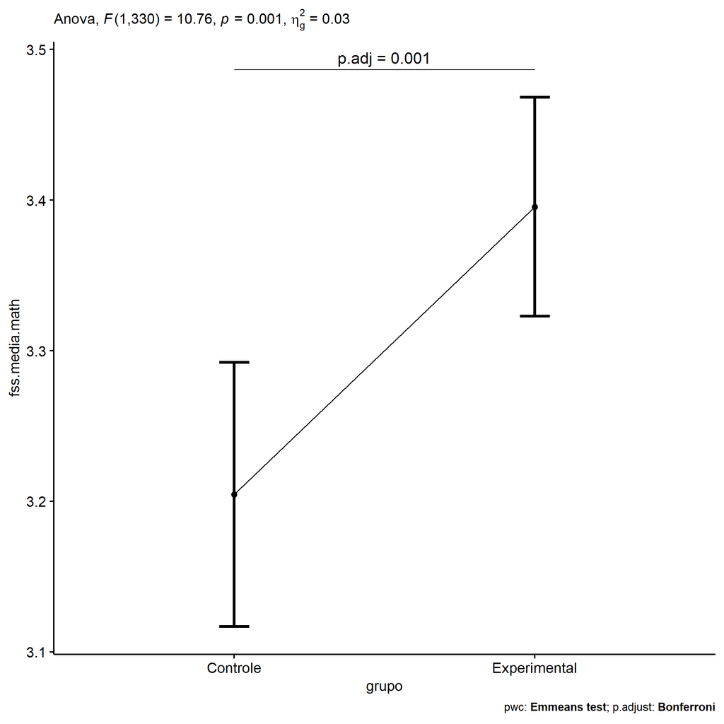

```r
if (!is.null(nrow(plots[["grupo"]]$data)))
  plots[["grupo"]] + ggplot2::scale_color_manual(values = color[["grupo"]])
```

```r
plots <- oneWayAncovaBoxPlots(
  wdat, "fss.media.math", "grupo", aov, pwc, covar = "dfs.media.math",
  theme = "classic", color = color[["grupo"]],
  subtitle = which(aov$Effect == "grupo"))
```

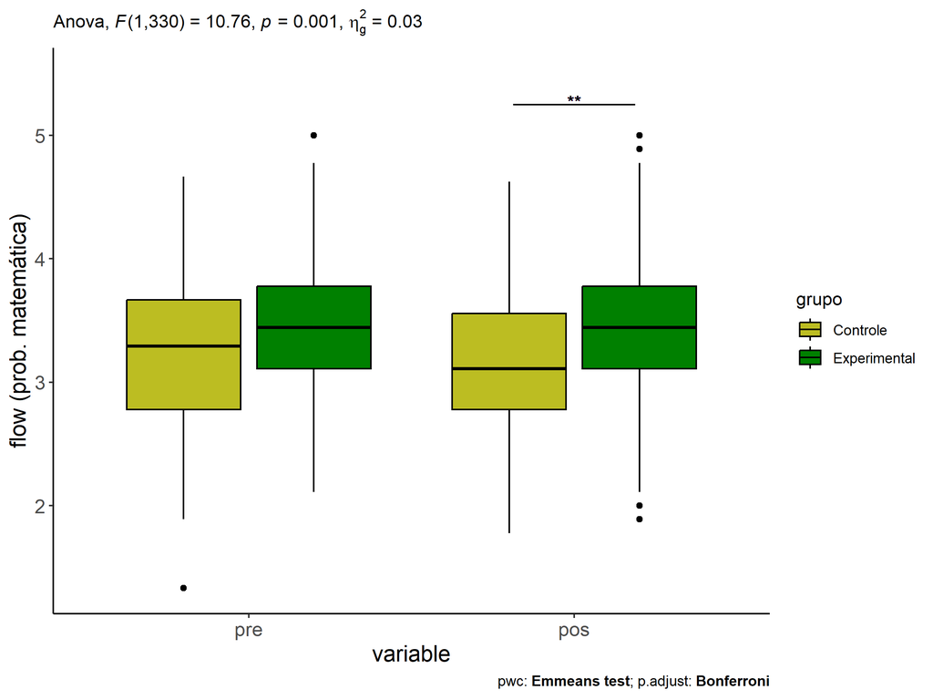

```r
if (length(unique(wdat[["grupo"]])) > 1)
  plots[["grupo"]] + ggplot2::ylab("flow (prob. matemática)") + ggplot2::scale_x_discrete(labels=c('pre', 'pos'))
```

```r
if (length(unique(wdat.long[["grupo"]])) > 1)
  plots <- oneWayAncovaBoxPlots(
    wdat.long, "flow.math", "grupo", aov, pwc.long, pre.post = "time",
    theme = "classic", color = color$prepost)
```

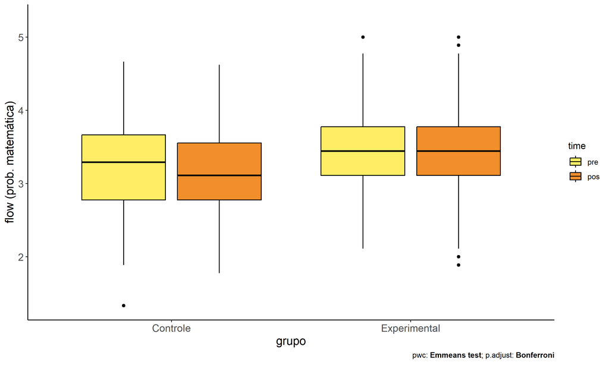

```r
if (length(unique(wdat.long[["grupo"]])) > 1)
  plots[["grupo"]] + ggplot2::ylab("flow (prob. matemática)")
```

### Checking linearity assumption

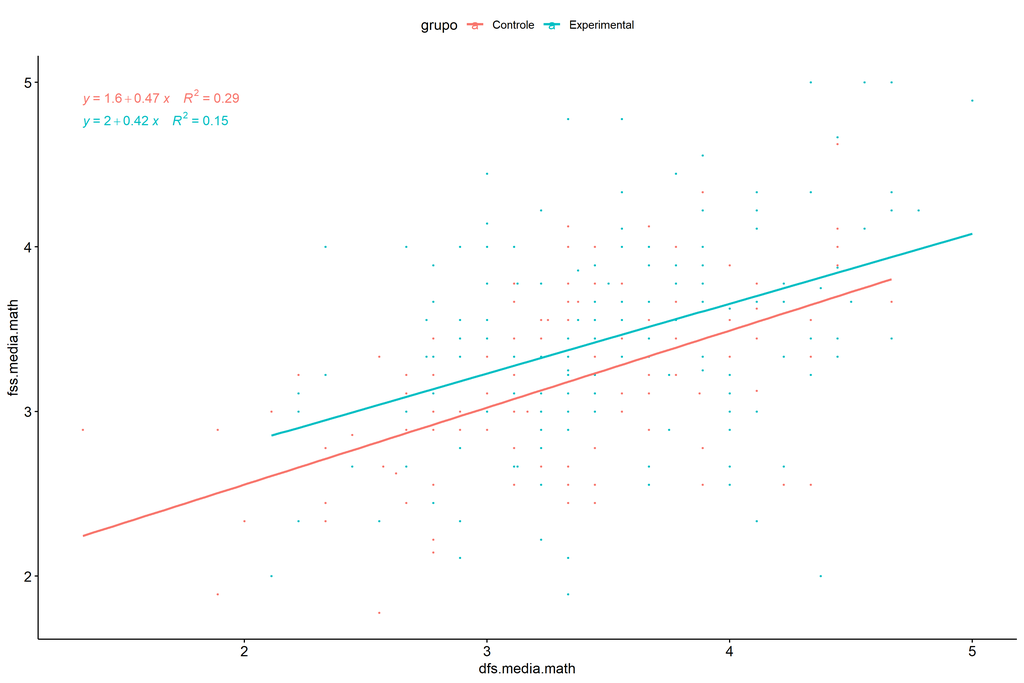

```r
ggscatter(wdat, x = "dfs.media.math", y = "fss.media.math", size = 0.5,
          color = "grupo", add = "reg.line")+
  stat_regline_equation(
    aes(label =  paste(..eq.label.., ..rr.label.., sep = "~~~~"), color = grupo)
  )
```

### Checking normality and homogeneity

```r
res <- augment(lm(fss.media.math ~ dfs.media.math + grupo, data = wdat))
```

```r
shapiro_test(res$.resid)
```

```
## # A tibble: 1 × 3
##   variable   statistic p.value
##   <chr>          <dbl>   <dbl>
## 1 res$.resid     0.996   0.505
```

```r
levene_test(res, .resid ~ grupo)
```

```
## # A tibble: 1 × 4
##     df1   df2 statistic      p
##   <int> <int>     <dbl>  <dbl>
## 1     1   331      3.60 0.0588
```

# ANCOVA and Pairwise for two factors **grupo:Sexo**

## Without remove non-normal data

```r
pdat = remove_group_data(dat[!is.na(dat[["grupo"]]) & !is.na(dat[["Sexo"]]),], "fss.media.math", c("grupo","Sexo"))

pdat.long <- rbind(pdat[,c("id","grupo","Sexo")], pdat[,c("id","grupo","Sexo")])
pdat.long[["time"]] <- c(rep("pre", nrow(pdat)), rep("pos", nrow(pdat)))
pdat.long[["time"]] <- factor(pdat.long[["time"]], c("pre","pos"))
pdat.long[["flow.math"]] <- c(pdat[["dfs.media.math"]], pdat[["fss.media.math"]])

aov = anova_test(pdat, fss.media.math ~ dfs.media.math + grupo*Sexo)
laov[["grupo:Sexo"]] <- get_anova_table(aov)
```

```r
pwcs <- list()
pwcs[["Sexo"]] <- emmeans_test(
  group_by(pdat, grupo), fss.media.math ~ Sexo,
  covariate = dfs.media.math, p.adjust.method = "bonferroni")
pwcs[["grupo"]] <- emmeans_test(
  group_by(pdat, Sexo), fss.media.math ~ grupo,
  covariate = dfs.media.math, p.adjust.method = "bonferroni")

pwc <- plyr::rbind.fill(pwcs[["grupo"]], pwcs[["Sexo"]])
pwc <- pwc[,c("grupo","Sexo", colnames(pwc)[!colnames(pwc) %in% c("grupo","Sexo")])]
```

```r
pwc.long <- emmeans_test(dplyr::group_by_at(pdat.long, c("grupo","Sexo")),
                         flow.math ~ time,
                         p.adjust.method = "bonferroni")
lpwc[["grupo:Sexo"]] <- plyr::rbind.fill(pwc, pwc.long)
```

```r
ds <- get.descriptives(pdat, "fss.media.math", c("grupo","Sexo"), covar = "dfs.media.math")
ds <- merge(ds[ds$variable != "dfs.media.math",],
            ds[ds$variable == "dfs.media.math", !colnames(ds) %in% c("variable")],
            by = c("grupo","Sexo"), all.x = T, suffixes = c("", ".dfs.media.math"))
ds <- merge(get_emmeans(pwcs[["grupo"]]), ds, by = c("grupo","Sexo"), suffixes = c(".emms", ""))
ds <- ds[,c("grupo","Sexo","n","mean.dfs.media.math","se.dfs.media.math","mean","se","emmean","se.emms")]

colnames(ds) <- c("grupo","Sexo", "N", paste0(c("M","SE")," (pre)"),
                  paste0(c("M","SE"), " (unadj)"), paste0(c("M", "SE"), " (adj)"))

lemms[["grupo:Sexo"]] <- ds
```

## Computing ANCOVA and PairWise After removing non-normal data (OK)

```r
wdat = pdat

res = residuals(lm(fss.media.math ~ dfs.media.math + grupo*Sexo, data = wdat))
non.normal = getNonNormal(res, wdat$id, plimit = 0.05)

wdat = wdat[!wdat$id %in% non.normal,]

wdat.long <- rbind(wdat[,c("id","grupo","Sexo")], wdat[,c("id","grupo","Sexo")])
wdat.long[["time"]] <- c(rep("pre", nrow(wdat)), rep("pos", nrow(wdat)))
wdat.long[["time"]] <- factor(wdat.long[["time"]], c("pre","pos"))
wdat.long[["flow.math"]] <- c(wdat[["dfs.media.math"]], wdat[["fss.media.math"]])


ldat[["grupo:Sexo"]] = wdat

(non.normal)
```

```
## [1] "P1848"
```

```r
aov = anova_test(wdat, fss.media.math ~ dfs.media.math + grupo*Sexo)
laov[["grupo:Sexo"]] <- merge(get_anova_table(aov), laov[["grupo:Sexo"]], by="Effect", suffixes = c("","'"))

(df = get_anova_table(aov))
```

```
## ANOVA Table (type II tests)
##
##           Effect DFn DFd      F        p p<.05     ges
## 1 dfs.media.math   1 328 81.784 1.36e-17     * 0.20000
## 2          grupo   1 328 10.268 1.00e-03     * 0.03000
## 3           Sexo   1 328  1.375 2.42e-01       0.00400
## 4     grupo:Sexo   1 328  0.285 5.93e-01       0.00087
```

| Effect | DFn | DFd | F | p | p<.05 | ges |
| --- | --- | --- | --- | --- | --- | --- |
| dfs.media.math | 1 | 328 | 81.784 | 0.000 | * | 0.200 |
| grupo | 1 | 328 | 10.268 | 0.001 | * | 0.030 |
| Sexo | 1 | 328 | 1.375 | 0.242 |  | 0.004 |
| grupo:Sexo | 1 | 328 | 0.285 | 0.593 |  | 0.001 |

```r
pwcs <- list()
pwcs[["Sexo"]] <- emmeans_test(
  group_by(wdat, grupo), fss.media.math ~ Sexo,
  covariate = dfs.media.math, p.adjust.method = "bonferroni")
pwcs[["grupo"]] <- emmeans_test(
  group_by(wdat, Sexo), fss.media.math ~ grupo,
  covariate = dfs.media.math, p.adjust.method = "bonferroni")

pwc <- plyr::rbind.fill(pwcs[["grupo"]], pwcs[["Sexo"]])
pwc <- pwc[,c("grupo","Sexo", colnames(pwc)[!colnames(pwc) %in% c("grupo","Sexo")])]
```

| grupo | Sexo | term | .y. | group1 | group2 | df | statistic | p | p.adj | p.adj.signif |
| --- | --- | --- | --- | --- | --- | --- | --- | --- | --- | --- |
|  | F | dfs.media.math*grupo | fss.media.math | Controle | Experimental | 328 | -2.698 | 0.007 | 0.007 | ** |
|  | M | dfs.media.math*grupo | fss.media.math | Controle | Experimental | 328 | -1.809 | 0.071 | 0.071 | ns |
| Controle |  | dfs.media.math*Sexo | fss.media.math | F | M | 328 | -1.158 | 0.248 | 0.248 | ns |
| Experimental |  | dfs.media.math*Sexo | fss.media.math | F | M | 328 | -0.550 | 0.583 | 0.583 | ns |

```r
pwc.long <- emmeans_test(dplyr::group_by_at(wdat.long, c("grupo","Sexo")),
                         flow.math ~ time,
                         p.adjust.method = "bonferroni")
lpwc[["grupo:Sexo"]] <- merge(plyr::rbind.fill(pwc, pwc.long), lpwc[["grupo:Sexo"]], by=c("grupo","Sexo","term",".y.","group1","group2"), suffixes = c("","'"))
```

| grupo | Sexo | term | .y. | group1 | group2 | df | statistic | p | p.adj | p.adj.signif |
| --- | --- | --- | --- | --- | --- | --- | --- | --- | --- | --- |
| Controle | F | time | flow.math | pre | pos | 658 | 2.282 | 0.023 | 0.023 | * |
| Controle | M | time | flow.math | pre | pos | 658 | 0.154 | 0.878 | 0.878 | ns |
| Experimental | F | time | flow.math | pre | pos | 658 | -0.014 | 0.989 | 0.989 | ns |
| Experimental | M | time | flow.math | pre | pos | 658 | 0.927 | 0.354 | 0.354 | ns |

```r
ds <- get.descriptives(wdat, "fss.media.math", c("grupo","Sexo"), covar = "dfs.media.math")
ds <- merge(ds[ds$variable != "dfs.media.math",],
            ds[ds$variable == "dfs.media.math", !colnames(ds) %in% c("variable")],
            by = c("grupo","Sexo"), all.x = T, suffixes = c("", ".dfs.media.math"))
ds <- merge(get_emmeans(pwcs[["grupo"]]), ds, by = c("grupo","Sexo"), suffixes = c(".emms", ""))
ds <- ds[,c("grupo","Sexo","n","mean.dfs.media.math","se.dfs.media.math","mean","se","emmean","se.emms")]

colnames(ds) <- c("grupo","Sexo", "N", paste0(c("M","SE")," (pre)"),
                  paste0(c("M","SE"), " (unadj)"), paste0(c("M", "SE"), " (adj)"))

lemms[["grupo:Sexo"]] <- merge(ds, lemms[["grupo:Sexo"]], by=c("grupo","Sexo"), suffixes = c("","'"))
```

| grupo | Sexo | N | M (pre) | SE (pre) | M (unadj) | SE (unadj) | M (adj) | SE (adj) |
| --- | --- | --- | --- | --- | --- | --- | --- | --- |
| Controle | F | 74 | 3.360 | 0.063 | 3.144 | 0.056 | 3.158 | 0.060 |
| Controle | M | 62 | 3.185 | 0.087 | 3.169 | 0.077 | 3.261 | 0.066 |
| Experimental | F | 94 | 3.358 | 0.055 | 3.359 | 0.065 | 3.374 | 0.053 |
| Experimental | M | 103 | 3.568 | 0.056 | 3.494 | 0.056 | 3.415 | 0.052 |

### Plots for ancova

```r
plots <- twoWayAncovaPlots(
  wdat, "fss.media.math", c("grupo","Sexo"), aov, pwcs, addParam = c("mean_se"),
  font.label.size=10, step.increase=0.05, p.label="p.adj",
  subtitle = which(aov$Effect == "grupo:Sexo"))
```

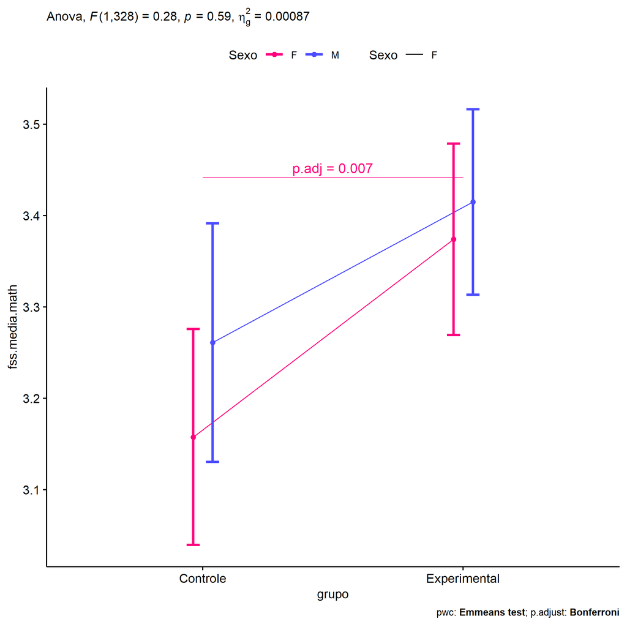

```r
if (!is.null(plots[["grupo"]]))
  plots[["grupo"]] + ggplot2::scale_color_manual(values = color[["Sexo"]])
```

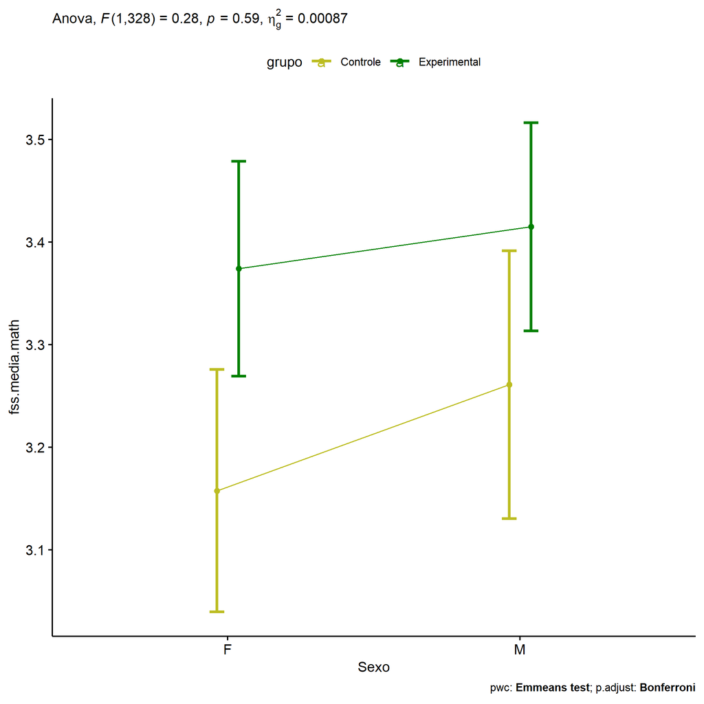

```r
if (!is.null(plots[["Sexo"]]))
  plots[["Sexo"]] + ggplot2::scale_color_manual(values = color[["grupo"]])
```

```r
plots <- twoWayAncovaBoxPlots(
  wdat, "fss.media.math", c("grupo","Sexo"), aov, pwcs, covar = "dfs.media.math",
  theme = "classic", color = color[["grupo:Sexo"]],
  subtitle = which(aov$Effect == "grupo:Sexo"))
```

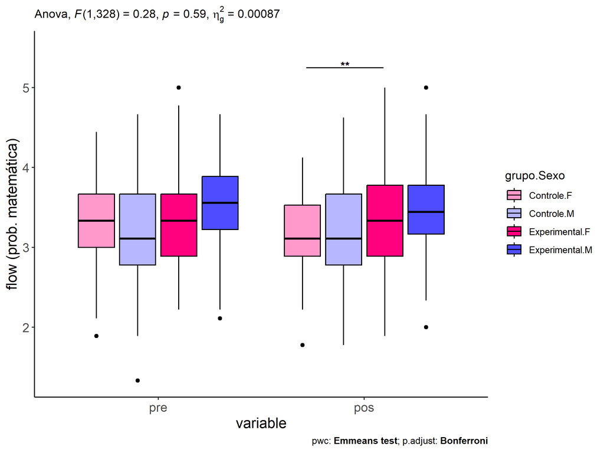

```r
plots[["grupo:Sexo"]] + ggplot2::ylab("flow (prob. matemática)") + ggplot2::scale_x_discrete(labels=c('pre', 'pos'))
```

```r
plots <- twoWayAncovaBoxPlots(
  wdat.long, "flow.math", c("grupo","Sexo"), aov, pwc.long, pre.post = "time",
  theme = "classic", color = color$prepost)
```

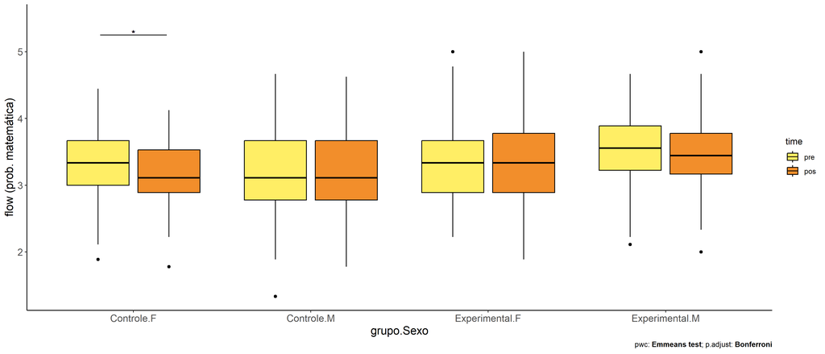

```r
plots[["grupo:Sexo"]] + ggplot2::ylab("flow (prob. matemática)")
```

### Checking linearity assumption

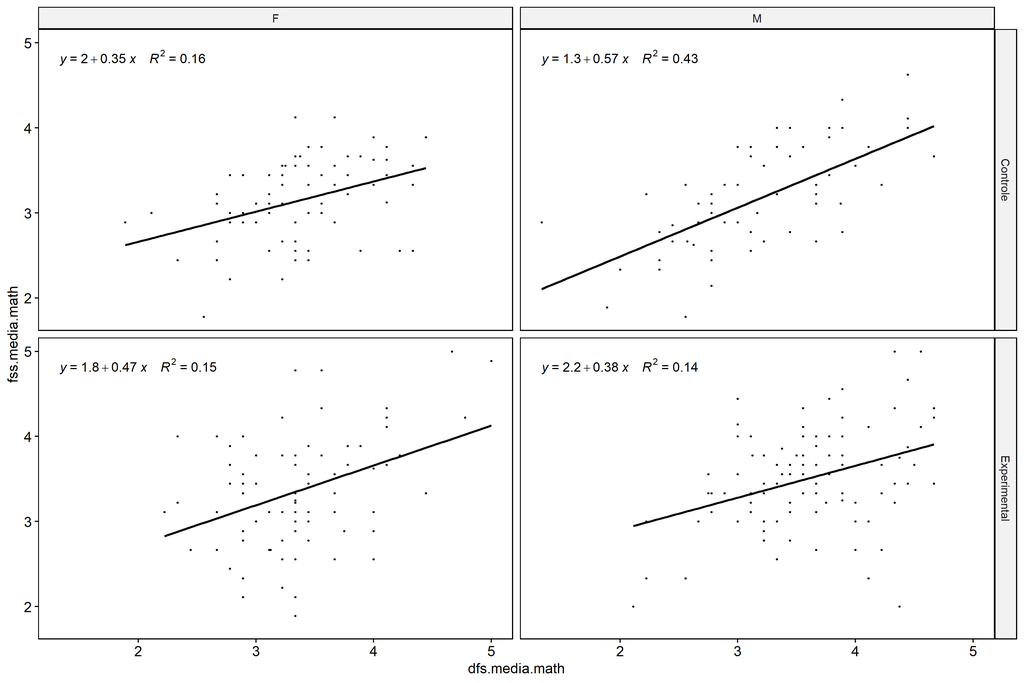

```r
ggscatter(wdat, x = "dfs.media.math", y = "fss.media.math", size = 0.5,
          facet.by = c("grupo","Sexo"), add = "reg.line")+
  stat_regline_equation(
    aes(label =  paste(..eq.label.., ..rr.label.., sep = "~~~~"))
  )
```

### Checking normality and homogeneity

```r
res <- augment(lm(fss.media.math ~ dfs.media.math + grupo*Sexo, data = wdat))
```

```r
shapiro_test(res$.resid)
```

```
## # A tibble: 1 × 3
##   variable   statistic p.value
##   <chr>          <dbl>   <dbl>
## 1 res$.resid     0.996   0.516
```

```r
levene_test(res, .resid ~ grupo*Sexo)
```

```
## # A tibble: 1 × 4
##     df1   df2 statistic     p
##   <int> <int>     <dbl> <dbl>
## 1     3   329      1.93 0.124
```

# ANCOVA and Pairwise for two factors **grupo:Zona**

## Without remove non-normal data

```r
pdat = remove_group_data(dat[!is.na(dat[["grupo"]]) & !is.na(dat[["Zona"]]),], "fss.media.math", c("grupo","Zona"))

pdat.long <- rbind(pdat[,c("id","grupo","Zona")], pdat[,c("id","grupo","Zona")])
pdat.long[["time"]] <- c(rep("pre", nrow(pdat)), rep("pos", nrow(pdat)))
pdat.long[["time"]] <- factor(pdat.long[["time"]], c("pre","pos"))
pdat.long[["flow.math"]] <- c(pdat[["dfs.media.math"]], pdat[["fss.media.math"]])

aov = anova_test(pdat, fss.media.math ~ dfs.media.math + grupo*Zona)
laov[["grupo:Zona"]] <- get_anova_table(aov)
```

```r
pwcs <- list()
pwcs[["Zona"]] <- emmeans_test(
  group_by(pdat, grupo), fss.media.math ~ Zona,
  covariate = dfs.media.math, p.adjust.method = "bonferroni")
pwcs[["grupo"]] <- emmeans_test(
  group_by(pdat, Zona), fss.media.math ~ grupo,
  covariate = dfs.media.math, p.adjust.method = "bonferroni")

pwc <- plyr::rbind.fill(pwcs[["grupo"]], pwcs[["Zona"]])
pwc <- pwc[,c("grupo","Zona", colnames(pwc)[!colnames(pwc) %in% c("grupo","Zona")])]
```

```r
pwc.long <- emmeans_test(dplyr::group_by_at(pdat.long, c("grupo","Zona")),
                         flow.math ~ time,
                         p.adjust.method = "bonferroni")
lpwc[["grupo:Zona"]] <- plyr::rbind.fill(pwc, pwc.long)
```

```r
ds <- get.descriptives(pdat, "fss.media.math", c("grupo","Zona"), covar = "dfs.media.math")
ds <- merge(ds[ds$variable != "dfs.media.math",],
            ds[ds$variable == "dfs.media.math", !colnames(ds) %in% c("variable")],
            by = c("grupo","Zona"), all.x = T, suffixes = c("", ".dfs.media.math"))
ds <- merge(get_emmeans(pwcs[["grupo"]]), ds, by = c("grupo","Zona"), suffixes = c(".emms", ""))
ds <- ds[,c("grupo","Zona","n","mean.dfs.media.math","se.dfs.media.math","mean","se","emmean","se.emms")]

colnames(ds) <- c("grupo","Zona", "N", paste0(c("M","SE")," (pre)"),
                  paste0(c("M","SE"), " (unadj)"), paste0(c("M", "SE"), " (adj)"))

lemms[["grupo:Zona"]] <- ds
```

## Computing ANCOVA and PairWise After removing non-normal data (OK)

```r
wdat = pdat

res = residuals(lm(fss.media.math ~ dfs.media.math + grupo*Zona, data = wdat))
non.normal = getNonNormal(res, wdat$id, plimit = 0.05)

wdat = wdat[!wdat$id %in% non.normal,]

wdat.long <- rbind(wdat[,c("id","grupo","Zona")], wdat[,c("id","grupo","Zona")])
wdat.long[["time"]] <- c(rep("pre", nrow(wdat)), rep("pos", nrow(wdat)))
wdat.long[["time"]] <- factor(wdat.long[["time"]], c("pre","pos"))
wdat.long[["flow.math"]] <- c(wdat[["dfs.media.math"]], wdat[["fss.media.math"]])


ldat[["grupo:Zona"]] = wdat

(non.normal)
```

```
## [1] "P1848"
```

```r
aov = anova_test(wdat, fss.media.math ~ dfs.media.math + grupo*Zona)
laov[["grupo:Zona"]] <- merge(get_anova_table(aov), laov[["grupo:Zona"]], by="Effect", suffixes = c("","'"))

(df = get_anova_table(aov))
```

```
## ANOVA Table (type II tests)
##
##           Effect DFn DFd      F        p p<.05      ges
## 1 dfs.media.math   1 280 75.816 2.75e-16     * 0.213000
## 2          grupo   1 280 11.947 6.32e-04     * 0.041000
## 3           Zona   1 280  0.113 7.37e-01       0.000402
## 4     grupo:Zona   1 280  4.626 3.20e-02     * 0.016000
```

| Effect | DFn | DFd | F | p | p<.05 | ges |
| --- | --- | --- | --- | --- | --- | --- |
| dfs.media.math | 1 | 280 | 75.816 | 0.000 | * | 0.213 |
| grupo | 1 | 280 | 11.947 | 0.001 | * | 0.041 |
| Zona | 1 | 280 | 0.113 | 0.737 |  | 0.000 |
| grupo:Zona | 1 | 280 | 4.626 | 0.032 | * | 0.016 |

```r
pwcs <- list()
pwcs[["Zona"]] <- emmeans_test(
  group_by(wdat, grupo), fss.media.math ~ Zona,
  covariate = dfs.media.math, p.adjust.method = "bonferroni")
pwcs[["grupo"]] <- emmeans_test(
  group_by(wdat, Zona), fss.media.math ~ grupo,
  covariate = dfs.media.math, p.adjust.method = "bonferroni")

pwc <- plyr::rbind.fill(pwcs[["grupo"]], pwcs[["Zona"]])
pwc <- pwc[,c("grupo","Zona", colnames(pwc)[!colnames(pwc) %in% c("grupo","Zona")])]
```

| grupo | Zona | term | .y. | group1 | group2 | df | statistic | p | p.adj | p.adj.signif |
| --- | --- | --- | --- | --- | --- | --- | --- | --- | --- | --- |
|  | Rural | dfs.media.math*grupo | fss.media.math | Controle | Experimental | 280 | -3.979 | 0.000 | 0.000 | **** |
|  | Urbana | dfs.media.math*grupo | fss.media.math | Controle | Experimental | 280 | -0.898 | 0.370 | 0.370 | ns |
| Controle |  | dfs.media.math*Zona | fss.media.math | Rural | Urbana | 280 | -1.429 | 0.154 | 0.154 | ns |
| Experimental |  | dfs.media.math*Zona | fss.media.math | Rural | Urbana | 280 | 1.645 | 0.101 | 0.101 | ns |

```r
pwc.long <- emmeans_test(dplyr::group_by_at(wdat.long, c("grupo","Zona")),
                         flow.math ~ time,
                         p.adjust.method = "bonferroni")
lpwc[["grupo:Zona"]] <- merge(plyr::rbind.fill(pwc, pwc.long), lpwc[["grupo:Zona"]], by=c("grupo","Zona","term",".y.","group1","group2"), suffixes = c("","'"))
```

| grupo | Zona | term | .y. | group1 | group2 | df | statistic | p | p.adj | p.adj.signif |
| --- | --- | --- | --- | --- | --- | --- | --- | --- | --- | --- |
| Controle | Rural | time | flow.math | pre | pos | 562 | 2.041 | 0.042 | 0.042 | * |
| Controle | Urbana | time | flow.math | pre | pos | 562 | 0.537 | 0.592 | 0.592 | ns |
| Experimental | Rural | time | flow.math | pre | pos | 562 | -0.764 | 0.445 | 0.445 | ns |
| Experimental | Urbana | time | flow.math | pre | pos | 562 | 1.295 | 0.196 | 0.196 | ns |

```r
ds <- get.descriptives(wdat, "fss.media.math", c("grupo","Zona"), covar = "dfs.media.math")
ds <- merge(ds[ds$variable != "dfs.media.math",],
            ds[ds$variable == "dfs.media.math", !colnames(ds) %in% c("variable")],
            by = c("grupo","Zona"), all.x = T, suffixes = c("", ".dfs.media.math"))
ds <- merge(get_emmeans(pwcs[["grupo"]]), ds, by = c("grupo","Zona"), suffixes = c(".emms", ""))
ds <- ds[,c("grupo","Zona","n","mean.dfs.media.math","se.dfs.media.math","mean","se","emmean","se.emms")]

colnames(ds) <- c("grupo","Zona", "N", paste0(c("M","SE")," (pre)"),
                  paste0(c("M","SE"), " (unadj)"), paste0(c("M", "SE"), " (adj)"))

lemms[["grupo:Zona"]] <- merge(ds, lemms[["grupo:Zona"]], by=c("grupo","Zona"), suffixes = c("","'"))
```

| grupo | Zona | N | M (pre) | SE (pre) | M (unadj) | SE (unadj) | M (adj) | SE (adj) |
| --- | --- | --- | --- | --- | --- | --- | --- | --- |
| Controle | Rural | 58 | 3.314 | 0.068 | 3.096 | 0.071 | 3.131 | 0.067 |
| Controle | Urbana | 60 | 3.262 | 0.089 | 3.206 | 0.064 | 3.265 | 0.066 |
| Experimental | Rural | 88 | 3.418 | 0.059 | 3.485 | 0.059 | 3.473 | 0.054 |
| Experimental | Urbana | 79 | 3.520 | 0.064 | 3.401 | 0.074 | 3.344 | 0.057 |

### Plots for ancova

```r
plots <- twoWayAncovaPlots(
  wdat, "fss.media.math", c("grupo","Zona"), aov, pwcs, addParam = c("mean_se"),
  font.label.size=10, step.increase=0.05, p.label="p.adj",
  subtitle = which(aov$Effect == "grupo:Zona"))
```

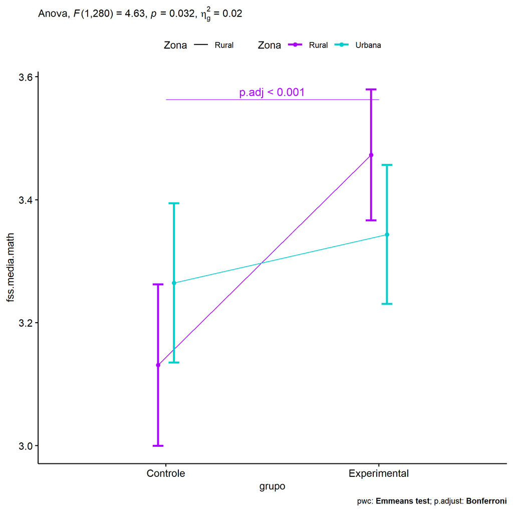

```r
if (!is.null(plots[["grupo"]]))
  plots[["grupo"]] + ggplot2::scale_color_manual(values = color[["Zona"]])
```

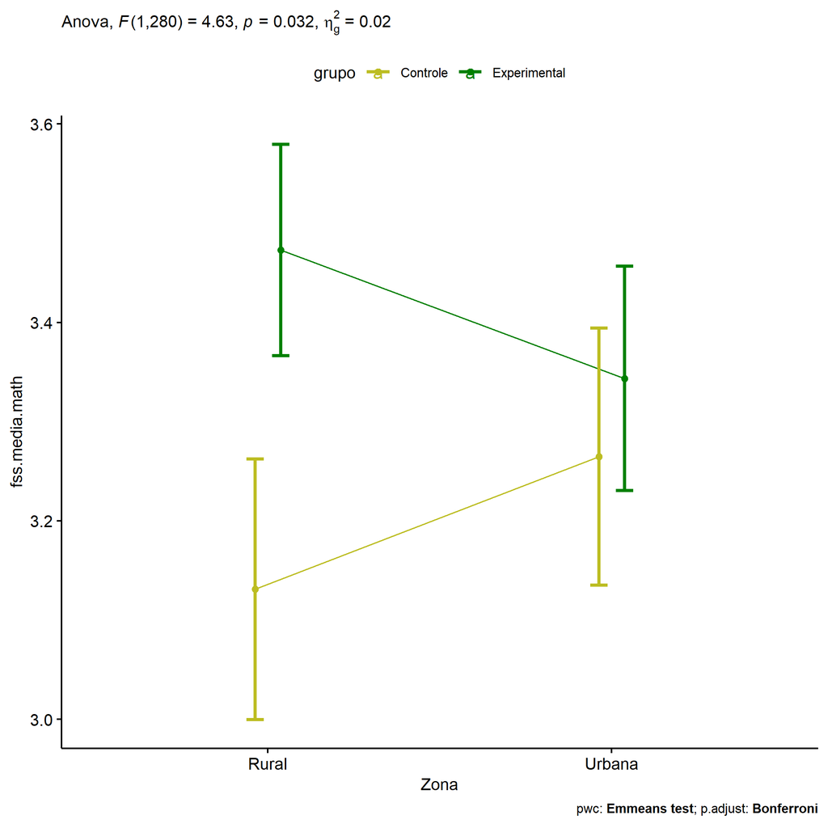

```r
if (!is.null(plots[["Zona"]]))
  plots[["Zona"]] + ggplot2::scale_color_manual(values = color[["grupo"]])
```

```r
plots <- twoWayAncovaBoxPlots(
  wdat, "fss.media.math", c("grupo","Zona"), aov, pwcs, covar = "dfs.media.math",
  theme = "classic", color = color[["grupo:Zona"]],
  subtitle = which(aov$Effect == "grupo:Zona"))
```

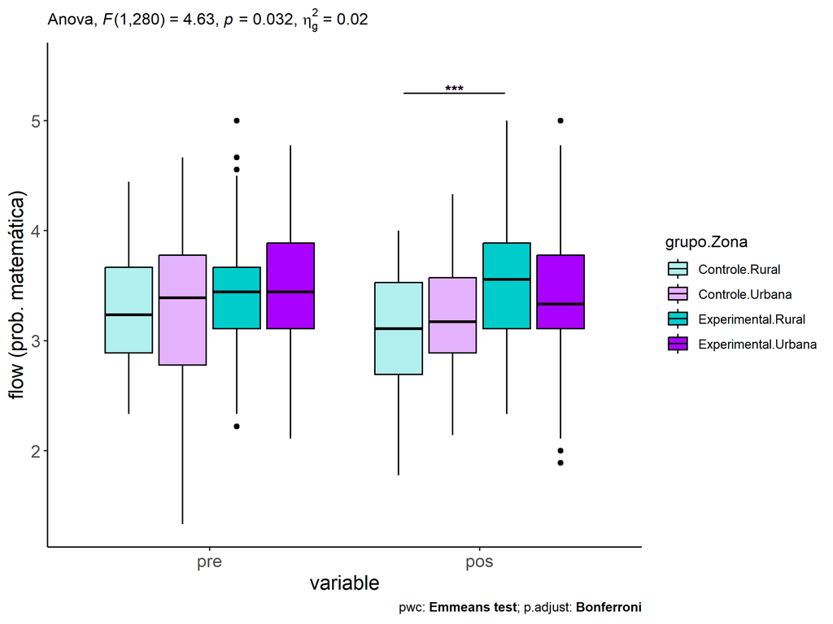

```r
plots[["grupo:Zona"]] + ggplot2::ylab("flow (prob. matemática)") + ggplot2::scale_x_discrete(labels=c('pre', 'pos'))
```

```r
plots <- twoWayAncovaBoxPlots(
  wdat.long, "flow.math", c("grupo","Zona"), aov, pwc.long, pre.post = "time",
  theme = "classic", color = color$prepost)
```

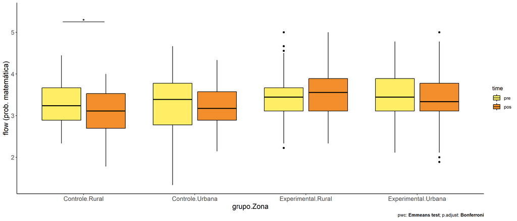

```r
plots[["grupo:Zona"]] + ggplot2::ylab("flow (prob. matemática)")
```

### Checking linearity assumption

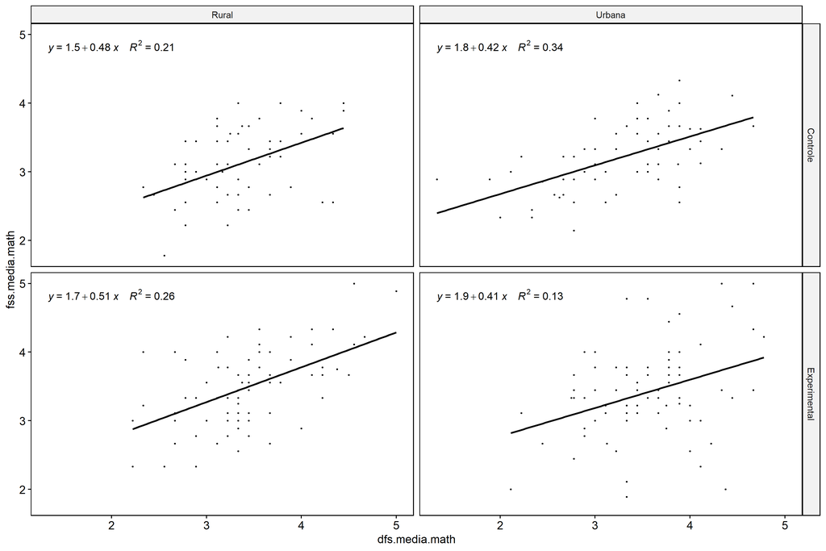

```r
ggscatter(wdat, x = "dfs.media.math", y = "fss.media.math", size = 0.5,
          facet.by = c("grupo","Zona"), add = "reg.line")+
  stat_regline_equation(
    aes(label =  paste(..eq.label.., ..rr.label.., sep = "~~~~"))
  )
```

### Checking normality and homogeneity

```r
res <- augment(lm(fss.media.math ~ dfs.media.math + grupo*Zona, data = wdat))
```

```r
shapiro_test(res$.resid)
```

```
## # A tibble: 1 × 3
##   variable   statistic p.value
##   <chr>          <dbl>   <dbl>
## 1 res$.resid     0.996   0.741
```

```r
levene_test(res, .resid ~ grupo*Zona)
```

```
## # A tibble: 1 × 4
##     df1   df2 statistic      p
##   <int> <int>     <dbl>  <dbl>
## 1     3   281      2.53 0.0575
```

# ANCOVA and Pairwise for two factors **grupo:Cor.Raca**

## Without remove non-normal data

```r
pdat = remove_group_data(dat[!is.na(dat[["grupo"]]) & !is.na(dat[["Cor.Raca"]]),], "fss.media.math", c("grupo","Cor.Raca"))

pdat.long <- rbind(pdat[,c("id","grupo","Cor.Raca")], pdat[,c("id","grupo","Cor.Raca")])
pdat.long[["time"]] <- c(rep("pre", nrow(pdat)), rep("pos", nrow(pdat)))
pdat.long[["time"]] <- factor(pdat.long[["time"]], c("pre","pos"))
pdat.long[["flow.math"]] <- c(pdat[["dfs.media.math"]], pdat[["fss.media.math"]])

aov = anova_test(pdat, fss.media.math ~ dfs.media.math + grupo*Cor.Raca)
laov[["grupo:Cor.Raca"]] <- get_anova_table(aov)
```

```r
pwcs <- list()
pwcs[["Cor.Raca"]] <- emmeans_test(
  group_by(pdat, grupo), fss.media.math ~ Cor.Raca,
  covariate = dfs.media.math, p.adjust.method = "bonferroni")
pwcs[["grupo"]] <- emmeans_test(
  group_by(pdat, Cor.Raca), fss.media.math ~ grupo,
  covariate = dfs.media.math, p.adjust.method = "bonferroni")

pwc <- plyr::rbind.fill(pwcs[["grupo"]], pwcs[["Cor.Raca"]])
pwc <- pwc[,c("grupo","Cor.Raca", colnames(pwc)[!colnames(pwc) %in% c("grupo","Cor.Raca")])]
```

```r
pwc.long <- emmeans_test(dplyr::group_by_at(pdat.long, c("grupo","Cor.Raca")),
                         flow.math ~ time,
                         p.adjust.method = "bonferroni")
lpwc[["grupo:Cor.Raca"]] <- plyr::rbind.fill(pwc, pwc.long)
```

```r
ds <- get.descriptives(pdat, "fss.media.math", c("grupo","Cor.Raca"), covar = "dfs.media.math")
ds <- merge(ds[ds$variable != "dfs.media.math",],
            ds[ds$variable == "dfs.media.math", !colnames(ds) %in% c("variable")],
            by = c("grupo","Cor.Raca"), all.x = T, suffixes = c("", ".dfs.media.math"))
ds <- merge(get_emmeans(pwcs[["grupo"]]), ds, by = c("grupo","Cor.Raca"), suffixes = c(".emms", ""))
ds <- ds[,c("grupo","Cor.Raca","n","mean.dfs.media.math","se.dfs.media.math","mean","se","emmean","se.emms")]

colnames(ds) <- c("grupo","Cor.Raca", "N", paste0(c("M","SE")," (pre)"),
                  paste0(c("M","SE"), " (unadj)"), paste0(c("M", "SE"), " (adj)"))

lemms[["grupo:Cor.Raca"]] <- ds
```

## Computing ANCOVA and PairWise After removing non-normal data (OK)

```r
wdat = pdat

res = residuals(lm(fss.media.math ~ dfs.media.math + grupo*Cor.Raca, data = wdat))
non.normal = getNonNormal(res, wdat$id, plimit = 0.05)

wdat = wdat[!wdat$id %in% non.normal,]

wdat.long <- rbind(wdat[,c("id","grupo","Cor.Raca")], wdat[,c("id","grupo","Cor.Raca")])
wdat.long[["time"]] <- c(rep("pre", nrow(wdat)), rep("pos", nrow(wdat)))
wdat.long[["time"]] <- factor(wdat.long[["time"]], c("pre","pos"))
wdat.long[["flow.math"]] <- c(wdat[["dfs.media.math"]], wdat[["fss.media.math"]])


ldat[["grupo:Cor.Raca"]] = wdat

(non.normal)
```

```r
aov = anova_test(wdat, fss.media.math ~ dfs.media.math + grupo*Cor.Raca)
laov[["grupo:Cor.Raca"]] <- merge(get_anova_table(aov), laov[["grupo:Cor.Raca"]], by="Effect", suffixes = c("","'"))

(df = get_anova_table(aov))
```

```
## ANOVA Table (type II tests)
##
##           Effect DFn DFd      F        p p<.05   ges
## 1 dfs.media.math   1 119 54.046 2.71e-11     * 0.312
## 2          grupo   1 119  1.622 2.05e-01       0.013
## 3       Cor.Raca   1 119  1.342 2.49e-01       0.011
## 4 grupo:Cor.Raca   1 119  8.774 4.00e-03     * 0.069
```

| Effect | DFn | DFd | F | p | p<.05 | ges |
| --- | --- | --- | --- | --- | --- | --- |
| dfs.media.math | 1 | 119 | 54.046 | 0.000 | * | 0.312 |
| grupo | 1 | 119 | 1.622 | 0.205 |  | 0.013 |
| Cor.Raca | 1 | 119 | 1.342 | 0.249 |  | 0.011 |
| grupo:Cor.Raca | 1 | 119 | 8.774 | 0.004 | * | 0.069 |

```r
pwcs <- list()
pwcs[["Cor.Raca"]] <- emmeans_test(
  group_by(wdat, grupo), fss.media.math ~ Cor.Raca,
  covariate = dfs.media.math, p.adjust.method = "bonferroni")
pwcs[["grupo"]] <- emmeans_test(
  group_by(wdat, Cor.Raca), fss.media.math ~ grupo,
  covariate = dfs.media.math, p.adjust.method = "bonferroni")

pwc <- plyr::rbind.fill(pwcs[["grupo"]], pwcs[["Cor.Raca"]])
pwc <- pwc[,c("grupo","Cor.Raca", colnames(pwc)[!colnames(pwc) %in% c("grupo","Cor.Raca")])]
```

| grupo | Cor.Raca | term | .y. | group1 | group2 | df | statistic | p | p.adj | p.adj.signif |
| --- | --- | --- | --- | --- | --- | --- | --- | --- | --- | --- |
|  | Branca | dfs.media.math*grupo | fss.media.math | Controle | Experimental | 119 | 1.896 | 0.060 | 0.060 | ns |
|  | Parda | dfs.media.math*grupo | fss.media.math | Controle | Experimental | 119 | -2.587 | 0.011 | 0.011 | * |
| Controle |  | dfs.media.math*Cor.Raca | fss.media.math | Branca | Parda | 119 | 1.208 | 0.229 | 0.229 | ns |
| Experimental |  | dfs.media.math*Cor.Raca | fss.media.math | Branca | Parda | 119 | -2.953 | 0.004 | 0.004 | ** |

```r
pwc.long <- emmeans_test(dplyr::group_by_at(wdat.long, c("grupo","Cor.Raca")),
                         flow.math ~ time,
                         p.adjust.method = "bonferroni")
lpwc[["grupo:Cor.Raca"]] <- merge(plyr::rbind.fill(pwc, pwc.long), lpwc[["grupo:Cor.Raca"]], by=c("grupo","Cor.Raca","term",".y.","group1","group2"), suffixes = c("","'"))
```

| grupo | Cor.Raca | term | .y. | group1 | group2 | df | statistic | p | p.adj | p.adj.signif |
| --- | --- | --- | --- | --- | --- | --- | --- | --- | --- | --- |
| Controle | Branca | time | flow.math | pre | pos | 240 | -0.082 | 0.934 | 0.934 | ns |
| Controle | Parda | time | flow.math | pre | pos | 240 | 1.702 | 0.090 | 0.090 | ns |
| Experimental | Branca | time | flow.math | pre | pos | 240 | 2.387 | 0.018 | 0.018 | * |
| Experimental | Parda | time | flow.math | pre | pos | 240 | -0.118 | 0.906 | 0.906 | ns |

```r
ds <- get.descriptives(wdat, "fss.media.math", c("grupo","Cor.Raca"), covar = "dfs.media.math")
ds <- merge(ds[ds$variable != "dfs.media.math",],
            ds[ds$variable == "dfs.media.math", !colnames(ds) %in% c("variable")],
            by = c("grupo","Cor.Raca"), all.x = T, suffixes = c("", ".dfs.media.math"))
ds <- merge(get_emmeans(pwcs[["grupo"]]), ds, by = c("grupo","Cor.Raca"), suffixes = c(".emms", ""))
ds <- ds[,c("grupo","Cor.Raca","n","mean.dfs.media.math","se.dfs.media.math","mean","se","emmean","se.emms")]

colnames(ds) <- c("grupo","Cor.Raca", "N", paste0(c("M","SE")," (pre)"),
                  paste0(c("M","SE"), " (unadj)"), paste0(c("M", "SE"), " (adj)"))

lemms[["grupo:Cor.Raca"]] <- merge(ds, lemms[["grupo:Cor.Raca"]], by=c("grupo","Cor.Raca"), suffixes = c("","'"))
```

| grupo | Cor.Raca | N | M (pre) | SE (pre) | M (unadj) | SE (unadj) | M (adj) | SE (adj) |
| --- | --- | --- | --- | --- | --- | --- | --- | --- |
| Controle | Branca | 18 | 3.208 | 0.163 | 3.224 | 0.114 | 3.329 | 0.116 |
| Controle | Parda | 43 | 3.356 | 0.090 | 3.140 | 0.082 | 3.163 | 0.074 |
| Experimental | Branca | 15 | 3.655 | 0.132 | 3.140 | 0.172 | 3.000 | 0.127 |
| Experimental | Parda | 48 | 3.432 | 0.085 | 3.446 | 0.091 | 3.429 | 0.070 |

### Plots for ancova

```r
plots <- twoWayAncovaPlots(
  wdat, "fss.media.math", c("grupo","Cor.Raca"), aov, pwcs, addParam = c("mean_se"),
  font.label.size=10, step.increase=0.05, p.label="p.adj",
  subtitle = which(aov$Effect == "grupo:Cor.Raca"))
```

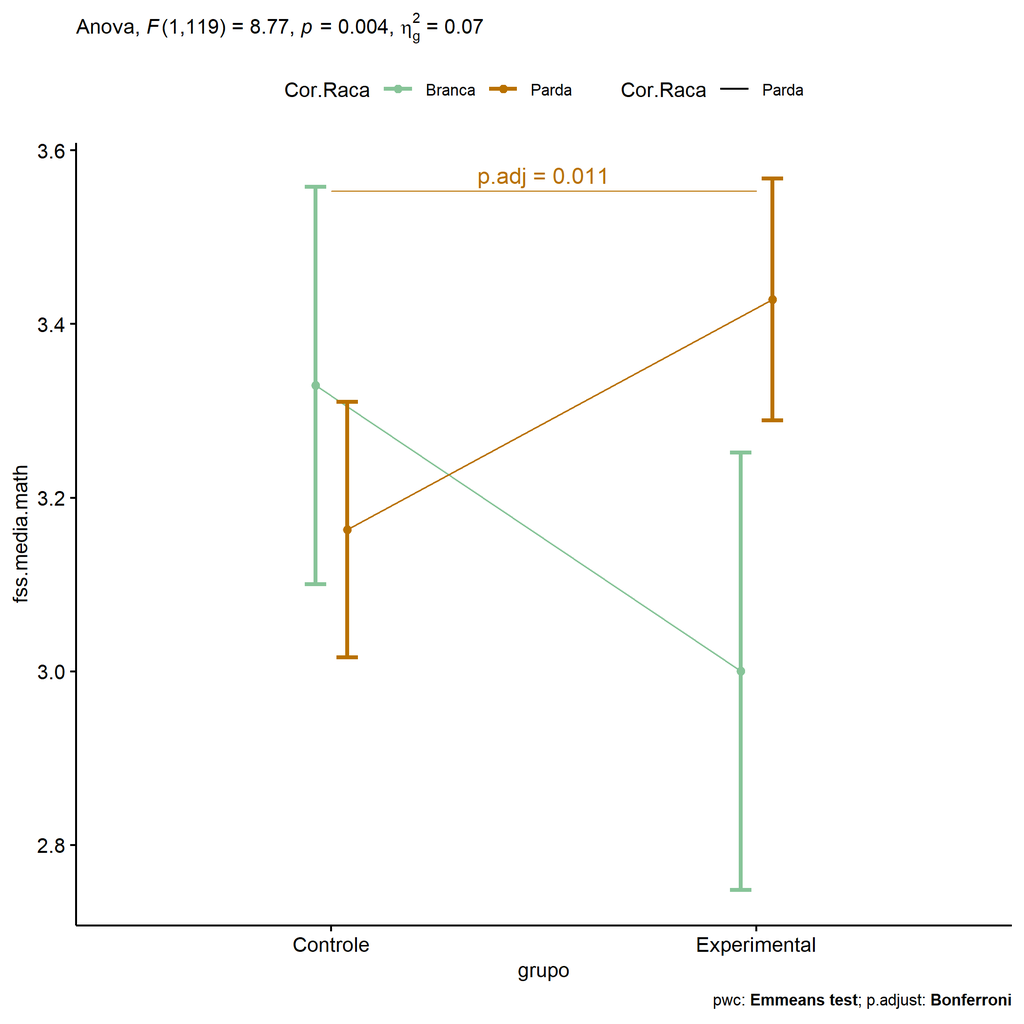

```r
if (!is.null(plots[["grupo"]]))
  plots[["grupo"]] + ggplot2::scale_color_manual(values = color[["Cor.Raca"]])
```

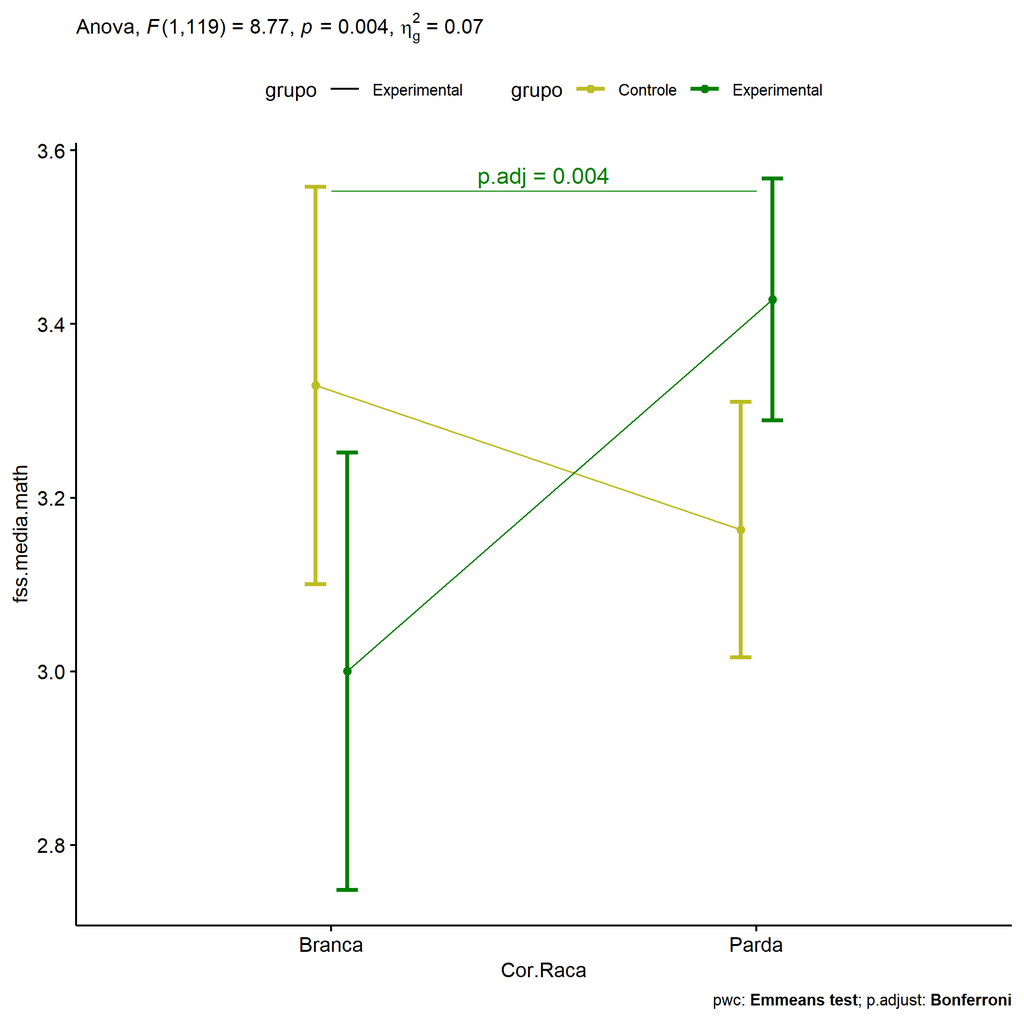

```r
if (!is.null(plots[["Cor.Raca"]]))
  plots[["Cor.Raca"]] + ggplot2::scale_color_manual(values = color[["grupo"]])
```

```r
plots <- twoWayAncovaBoxPlots(
  wdat, "fss.media.math", c("grupo","Cor.Raca"), aov, pwcs, covar = "dfs.media.math",
  theme = "classic", color = color[["grupo:Cor.Raca"]],
  subtitle = which(aov$Effect == "grupo:Cor.Raca"))
```

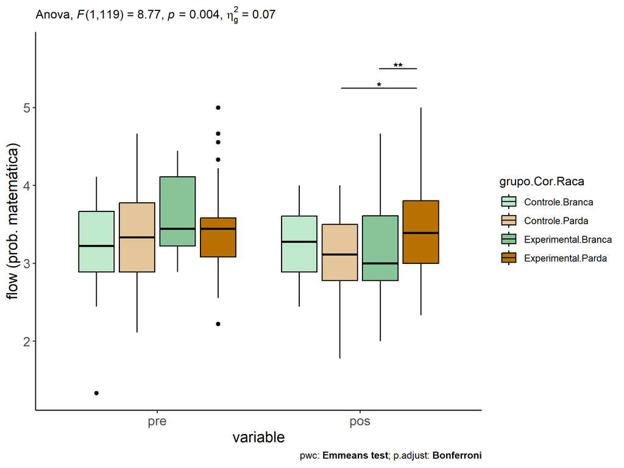

```r
plots[["grupo:Cor.Raca"]] + ggplot2::ylab("flow (prob. matemática)") + ggplot2::scale_x_discrete(labels=c('pre', 'pos'))
```

```r
plots <- twoWayAncovaBoxPlots(
  wdat.long, "flow.math", c("grupo","Cor.Raca"), aov, pwc.long, pre.post = "time",
  theme = "classic", color = color$prepost)
```

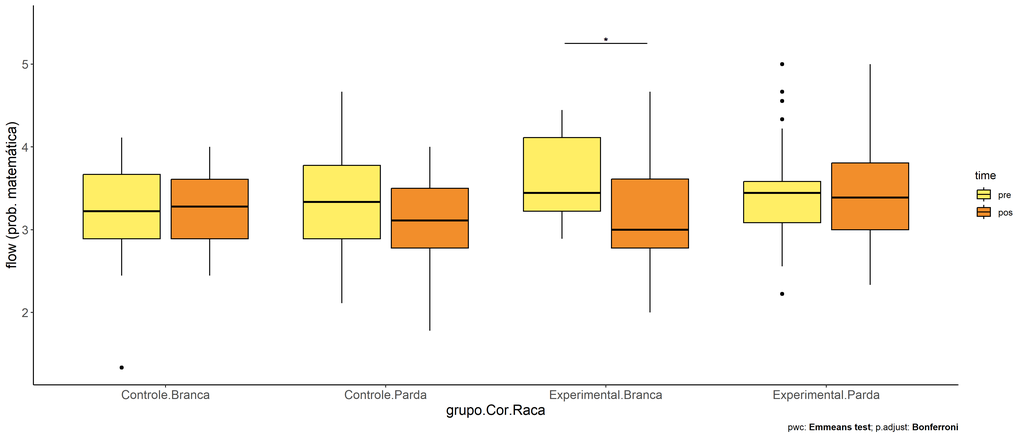

```r
plots[["grupo:Cor.Raca"]] + ggplot2::ylab("flow (prob. matemática)")
```

### Checking linearity assumption

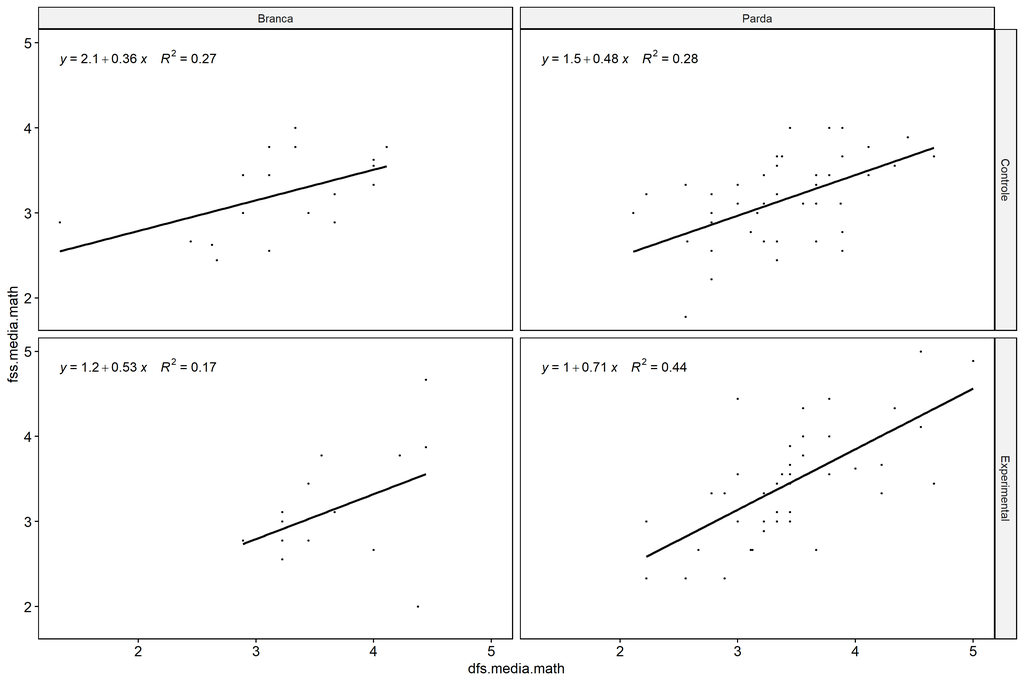

```r
ggscatter(wdat, x = "dfs.media.math", y = "fss.media.math", size = 0.5,
          facet.by = c("grupo","Cor.Raca"), add = "reg.line")+
  stat_regline_equation(
    aes(label =  paste(..eq.label.., ..rr.label.., sep = "~~~~"))
  )
```

### Checking normality and homogeneity

```r
res <- augment(lm(fss.media.math ~ dfs.media.math + grupo*Cor.Raca, data = wdat))
```

```r
shapiro_test(res$.resid)
```

```
## # A tibble: 1 × 3
##   variable   statistic p.value
##   <chr>          <dbl>   <dbl>
## 1 res$.resid     0.995   0.952
```

```r
levene_test(res, .resid ~ grupo*Cor.Raca)
```

```
## # A tibble: 1 × 4
##     df1   df2 statistic     p
##   <int> <int>     <dbl> <dbl>
## 1     3   120     0.211 0.889
```

# Summary of Results

## Descriptive Statistics

```r
df <- get.descriptives(ldat[["grupo"]], c(dv.pre, dv.pos), c("grupo"),
                       include.global = T, symmetry.test = T, normality.test = F)
df <- plyr::rbind.fill(
  df, do.call(plyr::rbind.fill, lapply(lfatores2, FUN = function(f) {
    if (nrow(dat) > 0 && sum(!is.na(unique(dat[[f]]))) > 1)
      get.descriptives(ldat[[paste0("grupo:",f)]], c(dv.pre,dv.pos), c("grupo", f),
                       symmetry.test = T, normality.test = F)
    }))
)
(df <- df[,c(fatores1[fatores1 %in% colnames(df)],"variable",
             colnames(df)[!colnames(df) %in% c(fatores1,"variable")])])
```

```
##           grupo Sexo   Zona Cor.Raca       variable   n  mean median   min   max    sd    se    ci   iqr
## 1      Controle <NA>   <NA>     <NA> dfs.media.math 136 3.280  3.292 1.333 4.667 0.619 0.053 0.105 0.889
## 2  Experimental <NA>   <NA>     <NA> dfs.media.math 197 3.468  3.444 2.111 5.000 0.558 0.040 0.078 0.667
## 3          <NA> <NA>   <NA>     <NA> dfs.media.math 333 3.391  3.333 1.333 5.000 0.590 0.032 0.064 0.778
## 4      Controle <NA>   <NA>     <NA> fss.media.math 136 3.155  3.111 1.778 4.625 0.537 0.046 0.091 0.778
## 5  Experimental <NA>   <NA>     <NA> fss.media.math 197 3.430  3.444 1.889 5.000 0.602 0.043 0.085 0.667
## 6          <NA> <NA>   <NA>     <NA> fss.media.math 333 3.318  3.333 1.778 5.000 0.591 0.032 0.064 0.778
## 7      Controle    F   <NA>     <NA> dfs.media.math  74 3.360  3.333 1.889 4.444 0.545 0.063 0.126 0.667
## 8      Controle    M   <NA>     <NA> dfs.media.math  62 3.185  3.111 1.333 4.667 0.688 0.087 0.175 0.889
## 9  Experimental    F   <NA>     <NA> dfs.media.math  94 3.358  3.333 2.222 5.000 0.531 0.055 0.109 0.778
## 10 Experimental    M   <NA>     <NA> dfs.media.math 103 3.568  3.556 2.111 4.667 0.565 0.056 0.110 0.667
## 11     Controle    F   <NA>     <NA> fss.media.math  74 3.144  3.111 1.778 4.125 0.478 0.056 0.111 0.639
## 12     Controle    M   <NA>     <NA> fss.media.math  62 3.169  3.111 1.778 4.625 0.605 0.077 0.154 0.889
## 13 Experimental    F   <NA>     <NA> fss.media.math  94 3.359  3.333 1.889 5.000 0.632 0.065 0.129 0.889
## 14 Experimental    M   <NA>     <NA> fss.media.math 103 3.494  3.444 2.000 5.000 0.569 0.056 0.111 0.611
```

[output cut: 47 more lines]

| grupo | Sexo | Zona | Cor.Raca | variable | n | mean | median | min | max | sd | se | ci | iqr | symmetry | skewness | kurtosis |
| --- | --- | --- | --- | --- | --- | --- | --- | --- | --- | --- | --- | --- | --- | --- | --- | --- |
| Controle |  |  |  | dfs.media.math | 136 | 3.280 | 3.292 | 1.333 | 4.667 | 0.619 | 0.053 | 0.105 | 0.889 | YES | -0.149 | -0.112 |
| Experimental |  |  |  | dfs.media.math | 197 | 3.468 | 3.444 | 2.111 | 5.000 | 0.558 | 0.040 | 0.078 | 0.667 | YES | 0.197 | -0.157 |
|  |  |  |  | dfs.media.math | 333 | 3.391 | 3.333 | 1.333 | 5.000 | 0.590 | 0.032 | 0.064 | 0.778 | YES | -0.019 | 0.027 |
| Controle |  |  |  | fss.media.math | 136 | 3.155 | 3.111 | 1.778 | 4.625 | 0.537 | 0.046 | 0.091 | 0.778 | YES | -0.051 | -0.243 |
| Experimental |  |  |  | fss.media.math | 197 | 3.430 | 3.444 | 1.889 | 5.000 | 0.602 | 0.043 | 0.085 | 0.667 | YES | 0.064 | 0.128 |
|  |  |  |  | fss.media.math | 333 | 3.318 | 3.333 | 1.778 | 5.000 | 0.591 | 0.032 | 0.064 | 0.778 | YES | 0.091 | 0.090 |
| Controle | F |  |  | dfs.media.math | 74 | 3.360 | 3.333 | 1.889 | 4.444 | 0.545 | 0.063 | 0.126 | 0.667 | YES | -0.079 | -0.248 |
| Controle | M |  |  | dfs.media.math | 62 | 3.185 | 3.111 | 1.333 | 4.667 | 0.688 | 0.087 | 0.175 | 0.889 | YES | -0.038 | -0.337 |
| Experimental | F |  |  | dfs.media.math | 94 | 3.358 | 3.333 | 2.222 | 5.000 | 0.531 | 0.055 | 0.109 | 0.778 | NO | 0.522 | 0.452 |
| Experimental | M |  |  | dfs.media.math | 103 | 3.568 | 3.556 | 2.111 | 4.667 | 0.565 | 0.056 | 0.110 | 0.667 | YES | -0.093 | -0.293 |
| Controle | F |  |  | fss.media.math | 74 | 3.144 | 3.111 | 1.778 | 4.125 | 0.478 | 0.056 | 0.111 | 0.639 | YES | -0.279 | -0.303 |
| Controle | M |  |  | fss.media.math | 62 | 3.169 | 3.111 | 1.778 | 4.625 | 0.605 | 0.077 | 0.154 | 0.889 | YES | 0.061 | -0.505 |
| Experimental | F |  |  | fss.media.math | 94 | 3.359 | 3.333 | 1.889 | 5.000 | 0.632 | 0.065 | 0.129 | 0.889 | YES | 0.185 | -0.114 |
| Experimental | M |  |  | fss.media.math | 103 | 3.494 | 3.444 | 2.000 | 5.000 | 0.569 | 0.056 | 0.111 | 0.611 | YES | -0.008 | 0.435 |
| Controle |  | Rural |  | dfs.media.math | 58 | 3.314 | 3.236 | 2.333 | 4.444 | 0.518 | 0.068 | 0.136 | 0.778 | YES | 0.403 | -0.506 |
| Controle |  | Urbana |  | dfs.media.math | 60 | 3.262 | 3.389 | 1.333 | 4.667 | 0.686 | 0.089 | 0.177 | 1.000 | YES | -0.405 | -0.256 |
| Experimental |  | Rural |  | dfs.media.math | 88 | 3.418 | 3.444 | 2.222 | 5.000 | 0.557 | 0.059 | 0.118 | 0.556 | YES | 0.292 | 0.202 |
| Experimental |  | Urbana |  | dfs.media.math | 79 | 3.520 | 3.444 | 2.111 | 4.778 | 0.571 | 0.064 | 0.128 | 0.778 | YES | 0.051 | -0.308 |
| Controle |  | Rural |  | fss.media.math | 58 | 3.096 | 3.111 | 1.778 | 4.000 | 0.540 | 0.071 | 0.142 | 0.833 | YES | -0.269 | -0.500 |
| Controle |  | Urbana |  | fss.media.math | 60 | 3.206 | 3.174 | 2.143 | 4.333 | 0.495 | 0.064 | 0.128 | 0.684 | YES | 0.097 | -0.657 |
| Experimental |  | Rural |  | fss.media.math | 88 | 3.485 | 3.556 | 2.333 | 5.000 | 0.552 | 0.059 | 0.117 | 0.778 | YES | 0.089 | -0.180 |
| Experimental |  | Urbana |  | fss.media.math | 79 | 3.401 | 3.333 | 1.889 | 5.000 | 0.660 | 0.074 | 0.148 | 0.667 | YES | 0.198 | 0.231 |
| Controle |  |  | Branca | dfs.media.math | 18 | 3.208 | 3.222 | 1.333 | 4.111 | 0.693 | 0.163 | 0.345 | 0.778 | NO | -0.836 | 0.572 |
| Controle |  |  | Parda | dfs.media.math | 43 | 3.356 | 3.333 | 2.111 | 4.667 | 0.591 | 0.090 | 0.182 | 0.889 | YES | -0.016 | -0.588 |
| Experimental |  |  | Branca | dfs.media.math | 15 | 3.655 | 3.444 | 2.889 | 4.444 | 0.513 | 0.132 | 0.284 | 0.889 | YES | 0.386 | -1.407 |
| Experimental |  |  | Parda | dfs.media.math | 48 | 3.432 | 3.444 | 2.222 | 5.000 | 0.586 | 0.085 | 0.170 | 0.500 | YES | 0.496 | 0.360 |
| Controle |  |  | Branca | fss.media.math | 18 | 3.224 | 3.278 | 2.444 | 4.000 | 0.482 | 0.114 | 0.240 | 0.719 | YES | -0.077 | -1.445 |
| Controle |  |  | Parda | fss.media.math | 43 | 3.140 | 3.111 | 1.778 | 4.000 | 0.538 | 0.082 | 0.166 | 0.722 | NO | -0.544 | 0.008 |
| Experimental |  |  | Branca | fss.media.math | 15 | 3.140 | 3.000 | 2.000 | 4.667 | 0.665 | 0.172 | 0.368 | 0.833 | NO | 0.573 | -0.274 |
| Experimental |  |  | Parda | fss.media.math | 48 | 3.446 | 3.389 | 2.333 | 5.000 | 0.632 | 0.091 | 0.183 | 0.806 | YES | 0.400 | -0.260 |

## ANCOVA Table Comparison

```r
df <- do.call(plyr::rbind.fill, laov)
(df <- df[!duplicated(df$Effect),])
```

```
##            Effect DFn DFd      F        p p<.05      ges DFn' DFd'     F'       p' p<.05'     ges'
## 1  dfs.media.math   1 330 83.640 6.26e-18     * 0.202000    1  331 77.809 6.63e-17      * 0.190000
## 2           grupo   1 330 10.755 1.00e-03     * 0.032000    1  331  8.869 3.00e-03      * 0.026000
## 5      grupo:Sexo   1 328  0.285 5.93e-01       0.000870    1  329  0.085 7.71e-01        0.000257
## 6            Sexo   1 328  1.375 2.42e-01       0.004000    1  329  1.963 1.62e-01        0.006000
## 9      grupo:Zona   1 280  4.626 3.20e-02     * 0.016000    1  281  5.352 2.10e-02      * 0.019000
## 10           Zona   1 280  0.113 7.37e-01       0.000402    1  281  0.377 5.39e-01        0.001000
## 11       Cor.Raca   1 119  1.342 2.49e-01       0.011000    1  119  1.342 2.49e-01        0.011000
## 14 grupo:Cor.Raca   1 119  8.774 4.00e-03     * 0.069000    1  119  8.774 4.00e-03      * 0.069000
```

|  | Effect | DFn | DFd | F | p | p<.05 | ges | DFn’ | DFd’ | F’ | p’ | p<.05’ | ges’ |
| --- | --- | --- | --- | --- | --- | --- | --- | --- | --- | --- | --- | --- | --- |
| 1 | dfs.media.math | 1 | 330 | 83.640 | 0.000 | * | 0.202 | 1 | 331 | 77.809 | 0.000 | * | 0.190 |
| 2 | grupo | 1 | 330 | 10.755 | 0.001 | * | 0.032 | 1 | 331 | 8.869 | 0.003 | * | 0.026 |
| 5 | grupo:Sexo | 1 | 328 | 0.285 | 0.593 |  | 0.001 | 1 | 329 | 0.085 | 0.771 |  | 0.000 |
| 6 | Sexo | 1 | 328 | 1.375 | 0.242 |  | 0.004 | 1 | 329 | 1.963 | 0.162 |  | 0.006 |
| 9 | grupo:Zona | 1 | 280 | 4.626 | 0.032 | * | 0.016 | 1 | 281 | 5.352 | 0.021 | * | 0.019 |
| 10 | Zona | 1 | 280 | 0.113 | 0.737 |  | 0.000 | 1 | 281 | 0.377 | 0.539 |  | 0.001 |
| 11 | Cor.Raca | 1 | 119 | 1.342 | 0.249 |  | 0.011 | 1 | 119 | 1.342 | 0.249 |  | 0.011 |
| 14 | grupo:Cor.Raca | 1 | 119 | 8.774 | 0.004 | * | 0.069 | 1 | 119 | 8.774 | 0.004 | * | 0.069 |

## PairWise Table Comparison

```r
df <- do.call(plyr::rbind.fill, lpwc)
df <- df[,c(names(lfatores), names(df)[!names(df) %in% c(names(lfatores),"term",".y.")])]
```

| grupo | Sexo | Zona | Cor.Raca | group1 | group2 | df | statistic | p | p.adj | p.adj.signif | df’ | statistic’ | p’ | p.adj’ | p.adj.signif’ |
| --- | --- | --- | --- | --- | --- | --- | --- | --- | --- | --- | --- | --- | --- | --- | --- |
| Controle |  |  |  | pre | pos | 662 | 1.776 | 0.076 | 0.076 | ns | 664 | 1.755 | 0.080 | 0.080 | ns |
| Experimental |  |  |  | pre | pos | 662 | 0.656 | 0.512 | 0.512 | ns | 664 | 0.866 | 0.387 | 0.387 | ns |
|  |  |  |  | Controle | Experimental | 330 | -3.279 | 0.001 | 0.001 | ** | 331 | -2.978 | 0.003 | 0.003 | ** |
| Controle | F |  |  | pre | pos | 658 | 2.282 | 0.023 | 0.023 | * | 660 | 2.257 | 0.024 | 0.024 | * |
| Controle | M |  |  | pre | pos | 658 | 0.154 | 0.878 | 0.878 | ns | 660 | 0.152 | 0.879 | 0.879 | ns |
| Controle |  |  |  | F | M | 328 | -1.158 | 0.248 | 0.248 | ns | 329 | -1.114 | 0.266 | 0.266 | ns |
| Experimental | F |  |  | pre | pos | 658 | -0.014 | 0.989 | 0.989 | ns | 660 | 0.304 | 0.761 | 0.761 | ns |
| Experimental | M |  |  | pre | pos | 658 | 0.927 | 0.354 | 0.354 | ns | 660 | 0.917 | 0.360 | 0.360 | ns |
| Experimental |  |  |  | F | M | 328 | -0.550 | 0.583 | 0.583 | ns | 329 | -0.883 | 0.378 | 0.378 | ns |
|  | F |  |  | Controle | Experimental | 328 | -2.698 | 0.007 | 0.007 | ** | 329 | -2.309 | 0.022 | 0.022 | * |
|  | M |  |  | Controle | Experimental | 328 | -1.809 | 0.071 | 0.071 | ns | 329 | -1.772 | 0.077 | 0.077 | ns |
| Controle |  |  |  | Rural | Urbana | 280 | -1.429 | 0.154 | 0.154 | ns | 281 | -1.377 | 0.170 | 0.170 | ns |
| Controle |  | Rural |  | pre | pos | 562 | 2.041 | 0.042 | 0.042 | * | 564 | 2.014 | 0.044 | 0.044 | * |
| Controle |  | Urbana |  | pre | pos | 562 | 0.537 | 0.592 | 0.592 | ns | 564 | 0.530 | 0.597 | 0.597 | ns |
| Experimental |  |  |  | Rural | Urbana | 280 | 1.645 | 0.101 | 0.101 | ns | 281 | 1.960 | 0.051 | 0.051 | ns |
| Experimental |  | Rural |  | pre | pos | 562 | -0.764 | 0.445 | 0.445 | ns | 564 | -0.754 | 0.451 | 0.451 | ns |
| Experimental |  | Urbana |  | pre | pos | 562 | 1.295 | 0.196 | 0.196 | ns | 564 | 1.615 | 0.107 | 0.107 | ns |
|  |  | Rural |  | Controle | Experimental | 280 | -3.979 | 0.000 | 0.000 | **** | 281 | -3.837 | 0.000 | 0.000 | *** |
|  |  | Urbana |  | Controle | Experimental | 280 | -0.898 | 0.370 | 0.370 | ns | 281 | -0.538 | 0.591 | 0.591 | ns |
| Controle |  |  | Branca | pre | pos | 240 | -0.082 | 0.934 | 0.934 | ns | 240 | -0.082 | 0.934 | 0.934 | ns |
| Controle |  |  |  | Branca | Parda | 119 | 1.208 | 0.229 | 0.229 | ns | 119 | 1.208 | 0.229 | 0.229 | ns |
| Controle |  |  | Parda | pre | pos | 240 | 1.702 | 0.090 | 0.090 | ns | 240 | 1.702 | 0.090 | 0.090 | ns |
| Experimental |  |  | Branca | pre | pos | 240 | 2.387 | 0.018 | 0.018 | * | 240 | 2.387 | 0.018 | 0.018 | * |
| Experimental |  |  |  | Branca | Parda | 119 | -2.953 | 0.004 | 0.004 | ** | 119 | -2.953 | 0.004 | 0.004 | ** |
| Experimental |  |  | Parda | pre | pos | 240 | -0.118 | 0.906 | 0.906 | ns | 240 | -0.118 | 0.906 | 0.906 | ns |
|  |  |  | Branca | Controle | Experimental | 119 | 1.896 | 0.060 | 0.060 | ns | 119 | 1.896 | 0.060 | 0.060 | ns |
|  |  |  | Parda | Controle | Experimental | 119 | -2.587 | 0.011 | 0.011 | * | 119 | -2.587 | 0.011 | 0.011 | * |

## EMMS Table Comparison

```r
df <- do.call(plyr::rbind.fill, lemms)
df[["N-N'"]] <- df[["N"]] - df[["N'"]]
df <- df[,c(names(lfatores), names(df)[!names(df) %in% names(lfatores)])]
```

| grupo | Sexo | Zona | Cor.Raca | N | M (pre) | SE (pre) | M (unadj) | SE (unadj) | M (adj) | SE (adj) | N’ | M (pre)’ | SE (pre)’ | M (unadj)’ | SE (unadj)’ | M (adj)’ | SE (adj)’ | N-N’ |
| --- | --- | --- | --- | --- | --- | --- | --- | --- | --- | --- | --- | --- | --- | --- | --- | --- | --- | --- |
| Controle |  |  |  | 136 | 3.280 | 0.053 | 3.155 | 0.046 | 3.205 | 0.045 | 136 | 3.280 | 0.053 | 3.155 | 0.046 | 3.205 | 0.046 | 0 |
| Experimental |  |  |  | 197 | 3.468 | 0.040 | 3.430 | 0.043 | 3.396 | 0.037 | 198 | 3.468 | 0.040 | 3.417 | 0.044 | 3.383 | 0.038 | -1 |
| Controle | F |  |  | 74 | 3.360 | 0.063 | 3.144 | 0.056 | 3.158 | 0.060 | 74 | 3.360 | 0.063 | 3.144 | 0.056 | 3.158 | 0.062 | 0 |
| Controle | M |  |  | 62 | 3.185 | 0.087 | 3.169 | 0.077 | 3.261 | 0.066 | 62 | 3.185 | 0.087 | 3.169 | 0.077 | 3.260 | 0.068 | 0 |
| Experimental | F |  |  | 94 | 3.358 | 0.055 | 3.359 | 0.065 | 3.374 | 0.053 | 95 | 3.360 | 0.054 | 3.334 | 0.069 | 3.348 | 0.055 | -1 |
| Experimental | M |  |  | 103 | 3.568 | 0.056 | 3.494 | 0.056 | 3.415 | 0.052 | 103 | 3.568 | 0.056 | 3.494 | 0.056 | 3.416 | 0.053 | 0 |
| Controle |  | Rural |  | 58 | 3.314 | 0.068 | 3.096 | 0.071 | 3.131 | 0.067 | 58 | 3.314 | 0.068 | 3.096 | 0.071 | 3.131 | 0.069 | 0 |
| Controle |  | Urbana |  | 60 | 3.262 | 0.089 | 3.206 | 0.064 | 3.265 | 0.066 | 60 | 3.262 | 0.089 | 3.206 | 0.064 | 3.265 | 0.068 | 0 |
| Experimental |  | Rural |  | 88 | 3.418 | 0.059 | 3.485 | 0.059 | 3.473 | 0.054 | 88 | 3.418 | 0.059 | 3.485 | 0.059 | 3.473 | 0.056 | 0 |
| Experimental |  | Urbana |  | 79 | 3.520 | 0.064 | 3.401 | 0.074 | 3.344 | 0.057 | 80 | 3.520 | 0.063 | 3.371 | 0.079 | 3.314 | 0.059 | -1 |
| Controle |  |  | Branca | 18 | 3.208 | 0.163 | 3.224 | 0.114 | 3.329 | 0.116 | 18 | 3.208 | 0.163 | 3.224 | 0.114 | 3.329 | 0.116 | 0 |
| Controle |  |  | Parda | 43 | 3.356 | 0.090 | 3.140 | 0.082 | 3.163 | 0.074 | 43 | 3.356 | 0.090 | 3.140 | 0.082 | 3.163 | 0.074 | 0 |
| Experimental |  |  | Branca | 15 | 3.655 | 0.132 | 3.140 | 0.172 | 3.000 | 0.127 | 15 | 3.655 | 0.132 | 3.140 | 0.172 | 3.000 | 0.127 | 0 |
| Experimental |  |  | Parda | 48 | 3.432 | 0.085 | 3.446 | 0.091 | 3.429 | 0.070 | 48 | 3.432 | 0.085 | 3.446 | 0.091 | 3.429 | 0.070 | 0 |